# 02_functional_profiling

- Show All Code
- Hide All Code
- View Source

Author

Gong Yuhang

Published

January 2, 2026

**Updated: 2026-01-09 23:53:43 CET.**

The purpose of this document is: 本文档是项目 pc047 (vCagAepitope) 的**功能分析模块**。

**核心问题**：CagA依赖性感染是否改变了肠道微生物的**代谢功能潜力**？

**分析逻辑**： - 01文档回答了”Who is there?“（物种组成）→ 发现细菌Beta多样性显著改变 - 本文档回答”What are they capable of?“（功能潜力）→ 验证”Functional Footprint”假说

**分析大纲**： 1. Part 1: 理解HUMAnN数据 & 数据导入 2. Part 2: 功能多样性分析（Alpha + Beta） 3. Part 3: 通路差异丰度分析（DAA） 4. Part 4: 驱动物种分析（哪个物种贡献了差异功能）

```r
suppressPackageStartupMessages({
  library(here)
  library(conflicted)
  library(tidyverse)
  library(data.table)
  library(mia)
  library(TreeSummarizedExperiment)
  library(readxl)
  library(miaViz)
  library(scuttle)
  library(patchwork)
  library(MatrixGenerics)
  library(stringr)
  library(ggpubr)
  library(scater)
  library(vegan)
  library(ggplot2)
  library(RColorBrewer)
  library(Maaslin2)
  devtools::load_all()
})

# 解决命名空间冲突
conflicts_prefer(base::setdiff)
conflicts_prefer(dplyr::filter)
conflicts_prefer(dplyr::select)
conflicts_prefer(dplyr::lag)
conflicts_prefer(dplyr::first)
conflicts_prefer(ggplot2::annotate)

set.seed(20261)
```

## 0.1 Part 1: 理解HUMAnN数据 & 数据导入

### 0.1.1 1.1 HUMAnN数据结构概述

HUMAnN (HMP Unified Metabolic Analysis Network) 是功能宏基因组分析的标准工具，输出三种主要数据：

1. **Gene families** (基因家族): UniRef90聚类的基因丰度
2. **Pathways** (代谢通路): MetaCyc数据库定义的代谢通路丰度 ← 本分析主要使用
3. **Reactions** (反应): 生化反应丰度

每种数据都有两个版本： - **Unstratified**: 通路总丰度（用于多样性和DAA分析） - **Stratified**: 按物种分解的丰度（用于驱动物种分析）

### 0.1.2 1.2 数据导入

```r
# 定义数据路径
humann_data_dir <- here::here(path_data, "humann4")

# 读取unstratified pathway abundance (主要分析对象)
pathway_unstrat <- fread(
  file.path(humann_data_dir, "humann4_pathabundance-step2-normalized_unstratified.tsv"),
  header = TRUE
)

# 查看数据维度
cat("=== Pathway Abundance (Unstratified) ===\n")
```

```
=== Pathway Abundance (Unstratified) ===
```

```r
cat("维度:", nrow(pathway_unstrat), "通路 x", ncol(pathway_unstrat) - 1, "样本\n\n")
```

```
维度: 642 通路 x 33 样本
```

```r
# 查看前几行
head(pathway_unstrat[, 1:5], 10)
```

```
                                                         # Pathway HUMAnN v4.0.0.alpha.1
                                                                                  <char>
 1:                                                                             UNMAPPED
 2:                                                                         UNINTEGRATED
 3:                                     1CMET2-PWY: folate transformations III (E. coli)
 4:           3-HYDROXYPHENYLACETATE-DEGRADATION-PWY: 4-hydroxyphenylacetate degradation
 5:                            ALL-CHORISMATE-PWY: superpathway of chorismate metabolism
 6:                     ALLANTOINDEG-PWY: superpathway of allantoin degradation in yeast
 7:                                            ANAEROFRUCAT-PWY: homolactic fermentation
 8:                                     ANAGLYCOLYSIS-PWY: glycolysis III (from glucose)
 9:               ARG+POLYAMINE-SYN: superpathway of arginine and polyamine biosynthesis
10: ARGDEG-PWY: superpathway of L-arginine, putrescine, and 4-aminobutanoate degradation
    ca01_Abundance ca02_Abundance ca03_Abundance ca04_Abundance
             <num>          <num>          <num>          <num>
 1:    6.05563e+05    3.52278e+05    2.61692e+05    7.37337e+05
 2:    3.69763e+05    6.28969e+05    7.03564e+05    2.42396e+05
 3:    1.44689e+02    1.15134e+02    2.19122e+02    1.21242e+02
 4:    0.00000e+00    0.00000e+00    0.00000e+00    0.00000e+00
 5:    0.00000e+00    0.00000e+00    0.00000e+00    0.00000e+00
 6:    3.49189e+00    2.57975e+00    4.19186e+00    3.97824e+00
 7:    1.14765e+02    1.03354e+02    1.72813e+02    1.08942e+02
 8:    3.46132e+02    2.69737e+02    5.01468e+02    2.83876e+02
 9:    1.55295e+01    7.20278e+00    1.34503e+01    9.38113e+00
10:    4.82346e-01    6.15985e-01    0.00000e+00    0.00000e+00
```

```r
# 理解特殊行：UNMAPPED 和 UNINTEGRATED
cat("=== 特殊行说明 ===\n")
```

```
=== 特殊行说明 ===
```

```r
cat("UNMAPPED: 无法比对到已知序列的reads比例\n")
```

```
UNMAPPED: 无法比对到已知序列的reads比例
```

```r
cat("UNINTEGRATED: reads比对成功但未能整合到通路\n\n")
```

```
UNINTEGRATED: reads比对成功但未能整合到通路
```

```r
# 检查UNMAPPED和UNINTEGRATED的比例
first_col_name <- colnames(pathway_unstrat)[1]
unmapped_row <- pathway_unstrat[get(first_col_name) == "UNMAPPED"]
unintegrated_row <- pathway_unstrat[get(first_col_name) == "UNINTEGRATED"]

cat("UNMAPPED 范围:",
    round(min(as.numeric(unmapped_row[, -1, with = FALSE])), 0), "-",
    round(max(as.numeric(unmapped_row[, -1, with = FALSE])), 0), "\n")
```

```
UNMAPPED 范围: 190494 - 965081
```

```r
cat("UNINTEGRATED 范围:",
    round(min(as.numeric(unintegrated_row[, -1, with = FALSE])), 0), "-",
    round(max(as.numeric(unintegrated_row[, -1, with = FALSE])), 0), "\n")
```

```
UNINTEGRATED 范围: 28106 - 766058
```

### 0.1.3 1.3 数据清洗：创建分析用矩阵

```r
# 移除UNMAPPED和UNINTEGRATED行（用于多样性分析）
pathway_clean <- pathway_unstrat[!get(first_col_name) %in% c("UNMAPPED", "UNINTEGRATED")]

cat("清洗后通路数量:", nrow(pathway_clean), "\n")
```

```
清洗后通路数量: 640
```

```r
# 转换为矩阵格式
pathway_names <- pathway_clean[[1]]
pathway_matrix <- as.matrix(pathway_clean[, -1, with = FALSE])
rownames(pathway_matrix) <- pathway_names

# 清理样本名（去除_Abundance后缀）
colnames(pathway_matrix) <- gsub("_Abundance$", "", colnames(pathway_matrix))

# 排除ca08样本
# 原因：01分析中发现ca08的Escherichia coli相对丰度异常偏高，
# 疑似检测过程中引入杂质污染，详见01_alpha_beta_diversity_analysis.qmd
# 为保持分析一致性，在功能分析中同样排除该样本
samples_to_exclude <- "ca08"
pathway_matrix <- pathway_matrix[, !colnames(pathway_matrix) %in% samples_to_exclude]
cat("排除样本:", samples_to_exclude, "\n")
```

```
排除样本: ca08
```

```r
# 查看矩阵结构
cat("\n矩阵维度:", nrow(pathway_matrix), "通路 x", ncol(pathway_matrix), "样本\n")
```

```
矩阵维度: 640 通路 x 32 样本
```

```r
cat("样本名:", paste(head(colnames(pathway_matrix), 5), collapse = ", "), "...\n")
```

```
样本名: ca01, ca02, ca03, ca04, ca05 ...
```

### 0.1.4 1.4 导入样本元数据

```r
# 直接从项目通用的 metadata 文件读取（不依赖 01qmd）
metadata <- readxl::read_xlsx(
  here::here("data", "metadata", "pc047-metadata.xlsx")
) |>
  column_to_rownames("sample_id")

# 确保样本名一致
common_samples <- base::intersect(colnames(pathway_matrix), rownames(metadata))
cat("共同样本数:", length(common_samples), "\n")
```

```
共同样本数: 32
```

```r
# 子集化并排序
pathway_matrix <- pathway_matrix[, common_samples]
metadata <- metadata[common_samples, ]

# 查看分组信息
cat("\n样本分组:\n")
```

```
样本分组:
```

```r
print(table(metadata$treatment_group))
```

```
ApcMUT_Ctrl ApcMUT_HpKO ApcMUT_HpWT  ApcWT_Ctrl  ApcWT_HpKO  ApcWT_HpWT
          4           4           5           9           5           5
```

### 0.1.5 1.5 创建TreeSummarizedExperiment对象

```r
# ------------------------------------------------------------------------------
# 创建TreeSummarizedExperiment对象
# 虽然pathway数据没有phylogenetic tree，但使用TSE可以：
# 1. 与mia生态系统完全兼容（addAlpha, addMDS, getPERMANOVA等）
# 2. 保持与01文档一致的数据结构
# 3. 便于后续扩展（如添加pathway层级信息作为rowTree）
# ------------------------------------------------------------------------------

# 创建pathway的rowData（包含通路名称信息）
humann_pathway_rowdata <- DataFrame(
  pathway_id = rownames(pathway_matrix),
  row.names = rownames(pathway_matrix)
)

# 创建TSE对象
tse_humann_pathway_ca <- TreeSummarizedExperiment(
  assays = list(abundance = pathway_matrix),
  colData = DataFrame(metadata),
  rowData = humann_pathway_rowdata
)

# 查看对象
cat("=== TSE HUMAnN Pathway 对象信息 ===\n")
```

```
=== TSE HUMAnN Pathway 对象信息 ===
```

```r
print(tse_humann_pathway_ca)
```

```
class: TreeSummarizedExperiment
dim: 640 32
metadata(0):
assays(1): abundance
rownames(640): 1CMET2-PWY: folate transformations III (E. coli)
  3-HYDROXYPHENYLACETATE-DEGRADATION-PWY: 4-hydroxyphenylacetate
  degradation ... VALDEG-PWY: L-valine degradation I VALSYN-PWY:
  L-valine biosynthesis
rowData names(1): pathway_id
colnames(32): ca01 ca02 ... ic03 ic04
colData names(11): mouse_id genotype ... path_r1 path_r2
reducedDimNames(0):
mainExpName: NULL
altExpNames(0):
rowLinks: NULL
rowTree: NULL
colLinks: NULL
colTree: NULL
```

```r
cat("\n")
```

```r
cat("类型:", class(tse_humann_pathway_ca)[1], "\n")
```

```
类型: TreeSummarizedExperiment
```

```r
cat("Assays:", assayNames(tse_humann_pathway_ca), "\n")
```

```
Assays: abundance
```

```r
cat("样本数:", ncol(tse_humann_pathway_ca), "\n")
```

```
样本数: 32
```

```r
cat("通路数:", nrow(tse_humann_pathway_ca), "\n")
```

```
通路数: 640
```

### 0.1.6 1.6 数据质量概览

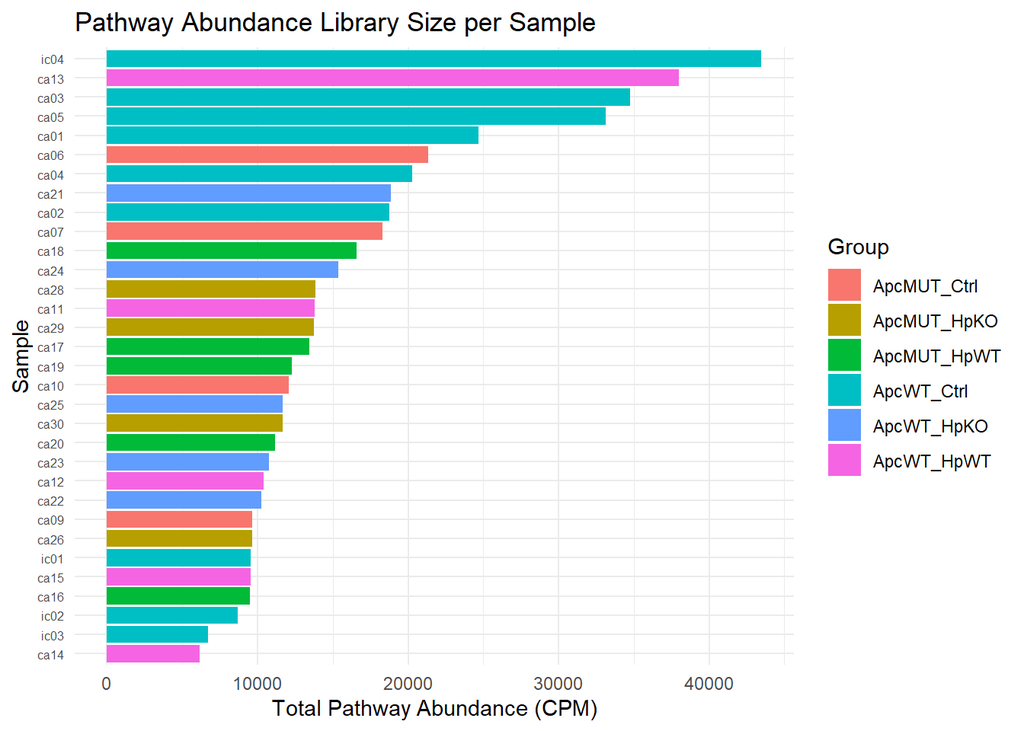

```r
# 计算每个样本的总通路丰度（library size）
library_sizes <- colSums(pathway_matrix)

# 可视化
library_df <- data.frame(
  sample = names(library_sizes),
  library_size = library_sizes,
  group = metadata$treatment_group  # 修改为 metadata 中实际存在的列名
)

p_libsize <- ggplot(library_df, aes(x = reorder(sample, library_size), y = library_size, fill = group)) +
  geom_bar(stat = "identity") +
  coord_flip() +
  labs(
    title = "Pathway Abundance Library Size per Sample",
    x = "Sample",
    y = "Total Pathway Abundance (CPM)",
    fill = "Group"
  ) +
  theme_minimal() +
  theme(axis.text.y = element_text(size = 6))

print(p_libsize)
```

```r
# 保存图表
ggsave(path_target("01_qc_pathway_library_size.png"), p_libsize,
       width = 10, height = 8, dpi = 150)
```

```r
# 保存TSE对象供后续分析使用
saveRDS(tse_humann_pathway_ca, path_target("tse_humann_pathway_ca.rds"))
cat("✓ TSE对象已保存:", path_target("tse_humann_pathway_ca.rds"), "\n")
```

```
✓ TSE对象已保存: C:/Users/36094/Desktop/pc047oma/analyses/data/02_functional_profiling/tse_humann_pathway_ca.rds
```

## 0.2 Part 2: 功能多样性分析

**科学问题**：CagA感染是否改变了肠道微生物组的功能多样性？

与物种多样性类似，功能多样性也可以从两个维度分析： - **Alpha多样性**：单个样本内的功能丰富度（有多少种代谢通路） - **Beta多样性**：样本间的功能组成差异（通路组成是否不同）

### 0.2.1 2.1 筛选核心比较组

```r
# ------------------------------------------------------------------------------
# 筛选核心比较组：ApcMUT_HpWT vs ApcMUT_HpKO
# 与01文档保持一致，聚焦于Apc突变背景下CagA的效应
# ------------------------------------------------------------------------------
tse_humann_pathway_ca_corepair <- tse_humann_pathway_ca[
  , tse_humann_pathway_ca$treatment_group %in% c("ApcMUT_HpWT", "ApcMUT_HpKO")
]

# 移除不再使用的因子水平
tse_humann_pathway_ca_corepair$treatment_group <- droplevels(
  factor(tse_humann_pathway_ca_corepair$treatment_group)
)

cat("=== 核心比较组样本信息 ===\n")
```

```
=== 核心比较组样本信息 ===
```

```r
cat("样本数:", ncol(tse_humann_pathway_ca_corepair), "\n")
```

```
样本数: 9
```

```r
cat("通路数:", nrow(tse_humann_pathway_ca_corepair), "\n\n")
```

```
通路数: 640
```

```r
print(table(tse_humann_pathway_ca_corepair$treatment_group))
```

```
ApcMUT_HpKO ApcMUT_HpWT
          4           5
```

### 0.2.2 2.2 Alpha多样性分析

```r
# ------------------------------------------------------------------------------
# 使用mia包的addAlpha()函数计算Alpha多样性
# 直接在TSE对象内部完成计算，结果存入colData
# ------------------------------------------------------------------------------
tse_humann_pathway_ca_corepair <- addAlpha(
  tse_humann_pathway_ca_corepair,
  assay.type = "abundance",
  index = c("shannon", "observed"),
  name = c("humann_shannon_index", "humann_observed_richness")
)

# 查看计算结果
cat("=== Alpha多样性计算完成 ===\n")
```

```
=== Alpha多样性计算完成 ===
```

```r
head(colData(tse_humann_pathway_ca_corepair)[, c("treatment_group", "humann_shannon_index", "humann_observed_richness")])
```

```
DataFrame with 6 rows and 3 columns
     treatment_group humann_shannon_index humann_observed_richness
            <factor>            <numeric>                <numeric>
ca16     ApcMUT_HpWT              5.38880                      481
ca17     ApcMUT_HpWT              5.40518                      489
ca18     ApcMUT_HpWT              5.28194                      498
ca19     ApcMUT_HpWT              5.38429                      495
ca20     ApcMUT_HpWT              5.30799                      510
ca26     ApcMUT_HpKO              5.40597                      494
```

```r
# ------------------------------------------------------------------------------
# Alpha多样性统计检验
# ------------------------------------------------------------------------------
humann_alpha_df <- as.data.frame(colData(tse_humann_pathway_ca_corepair))

# Wilcoxon检验 - Observed Richness
humann_wilcox_richness <- wilcox.test(
  humann_observed_richness ~ treatment_group,
  data = humann_alpha_df
)

# Wilcoxon检验 - Shannon
humann_wilcox_shannon <- wilcox.test(
  humann_shannon_index ~ treatment_group,
  data = humann_alpha_df
)

cat("=== 功能Alpha多样性统计检验 ===\n\n")
```

```
=== 功能Alpha多样性统计检验 ===
```

```r
cat("Observed Richness (通路数量):\n")
```

```
Observed Richness (通路数量):
```

```r
cat("  W =", humann_wilcox_richness$statistic,
    ", p-value =", round(humann_wilcox_richness$p.value, 4), "\n\n")
```

```
  W = 12 , p-value = 0.7302
```

```r
cat("Shannon Index (多样性指数):\n")
```

```
Shannon Index (多样性指数):
```

```r
cat("  W =", humann_wilcox_shannon$statistic,
    ", p-value =", round(humann_wilcox_shannon$p.value, 4), "\n")
```

```
  W = 20 , p-value = 0.0159
```

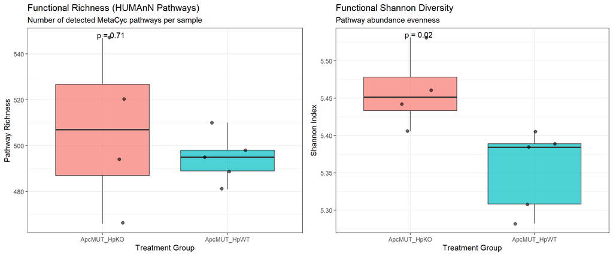

```r
# ------------------------------------------------------------------------------
# Alpha多样性可视化
# ------------------------------------------------------------------------------

# Richness箱线图
p2_1_humann_richness <- ggplot(
  humann_alpha_df,
  aes(x = treatment_group, y = humann_observed_richness, fill = treatment_group)
) +
  geom_boxplot(outlier.shape = NA, alpha = 0.7) +
  geom_jitter(width = 0.2, size = 2, alpha = 0.6) +
  stat_compare_means(method = "wilcox.test", label = "p.format") +
  labs(
    title = "Functional Richness (HUMAnN Pathways)",
    subtitle = "Number of detected MetaCyc pathways per sample",
    x = "Treatment Group",
    y = "Pathway Richness"
  ) +
  theme_bw() +
  theme(legend.position = "none")

# Shannon箱线图
p2_1_humann_shannon <- ggplot(
  humann_alpha_df,
  aes(x = treatment_group, y = humann_shannon_index, fill = treatment_group)
) +
  geom_boxplot(outlier.shape = NA, alpha = 0.7) +
  geom_jitter(width = 0.2, size = 2, alpha = 0.6) +
  stat_compare_means(method = "wilcox.test", label = "p.format") +
  labs(
    title = "Functional Shannon Diversity",
    subtitle = "Pathway abundance evenness",
    x = "Treatment Group",
    y = "Shannon Index"
  ) +
  theme_bw() +
  theme(legend.position = "none")

# 组合图
p2_1_humann_alpha_combined <- ggarrange(
  p2_1_humann_richness, p2_1_humann_shannon,
  ncol = 2, nrow = 1
)
print(p2_1_humann_alpha_combined)
```

```r
# 保存
ggsave(
  path_target("02_alpha_diversity_humann_pathway.png"),
  p2_1_humann_alpha_combined,
  width = 12, height = 5, dpi = 300
)
```

### 0.2.3 2.3 Beta多样性分析

```r
# ------------------------------------------------------------------------------
# 转换为相对丰度用于Beta多样性分析
# ------------------------------------------------------------------------------
tse_humann_pathway_ca_corepair <- transformAssay(
  tse_humann_pathway_ca_corepair,
  assay.type = "abundance",
  method = "relabundance"
)

cat("=== 相对丰度转换完成 ===\n")
```

```
=== 相对丰度转换完成 ===
```

```r
cat("Assays:", assayNames(tse_humann_pathway_ca_corepair), "\n")
```

```
Assays: abundance relabundance
```

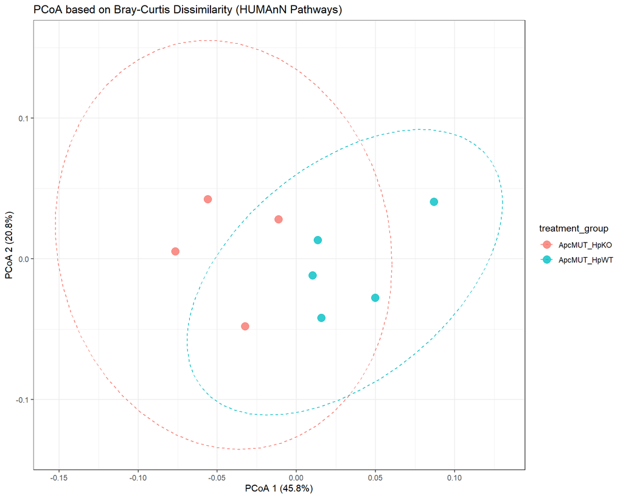

```r
# ------------------------------------------------------------------------------
# 计算Bray-Curtis距离并进行PCoA降维
# ------------------------------------------------------------------------------
tse_humann_pathway_ca_corepair <- addMDS(
  tse_humann_pathway_ca_corepair,
  assay.type = "relabundance",
  method = "bray",
  name = "PCoA_bray"
)

# 提取PCoA结果和特征值
humann_pcoa_bray <- reducedDim(tse_humann_pathway_ca_corepair, "PCoA_bray")
humann_eigenvalues_bray <- attr(humann_pcoa_bray, "eig")
humann_relative_eigenvalues_bray <- humann_eigenvalues_bray / sum(humann_eigenvalues_bray)

# 创建绘图数据框
humann_pcoa_df <- data.frame(
  PC1 = humann_pcoa_bray[, 1],
  PC2 = humann_pcoa_bray[, 2],
  treatment_group = colData(tse_humann_pathway_ca_corepair)$treatment_group
)

# PCoA可视化
p2_2_humann_pcoa <- ggplot(
  humann_pcoa_df,
  aes(x = PC1, y = PC2, color = treatment_group)
) +
  geom_point(size = 4, alpha = 0.8) +
  stat_ellipse(level = 0.95, linetype = "dashed") +
  theme_bw() +
  labs(
    title = "PCoA based on Bray-Curtis Dissimilarity (HUMAnN Pathways)",
    x = paste0("PCoA 1 (", round(100 * humann_relative_eigenvalues_bray[1], 1), "%)"),
    y = paste0("PCoA 2 (", round(100 * humann_relative_eigenvalues_bray[2], 1), "%)")
  )

print(p2_2_humann_pcoa)
```

```r
# 保存
ggsave(
  path_target("03_beta_pcoa_bray_humann_pathway.png"),
  p2_2_humann_pcoa,
  width = 10, height = 8, dpi = 300
)
```

```r
# ------------------------------------------------------------------------------
# PERMANOVA检验：功能组成是否在组间存在显著差异
# 使用mia包的getPERMANOVA()函数
# ------------------------------------------------------------------------------
humann_pathway_permanova_result <- getPERMANOVA(
  tse_humann_pathway_ca_corepair,
  assay.type = "relabundance",
  formula = x ~ treatment_group
)

cat("=== PERMANOVA分析 (HUMAnN Pathways) ===\n\n")
```

```
=== PERMANOVA分析 (HUMAnN Pathways) ===
```

```r
print(humann_pathway_permanova_result$permanova)
```

```
Permutation test for adonis under reduced model
Marginal effects of terms
Permutation: free
Number of permutations: 999

adonis2(formula = formula, data = data, method = ..1, by = by, na.action = na.action)
                Df SumOfSqs      R2      F Pr(>F)
treatment_group  1 0.015268 0.33089 3.4616  0.012 *
Residual         7 0.030876 0.66911
Total            8 0.046144 1.00000
---
Signif. codes:  0 '***' 0.001 '**' 0.01 '*' 0.05 '.' 0.1 ' ' 1
```

```r
# 保存PERMANOVA结果
write.csv(
  humann_pathway_permanova_result$permanova,
  file = path_target("04_permanova_bray_humann_pathway.csv"),
  row.names = TRUE
)

cat("\n解读：\n")
```

```
解读：
```

```r
humann_permanova_p <- humann_pathway_permanova_result$permanova$`Pr(>F)`[1]
humann_permanova_r2 <- humann_pathway_permanova_result$permanova$R2[1]
cat("- R² =", round(humann_permanova_r2, 4),
    "表示组间差异解释了", round(humann_permanova_r2 * 100, 1), "% 的功能变异\n")
```

```
- R² = 0.3309 表示组间差异解释了 33.1 % 的功能变异
```

```r
cat("- p-value =", humann_permanova_p, "\n")
```

```
- p-value = 0.012
```

```r
if (humann_permanova_p < 0.05) {
  cat("- 结论：功能组成在两组之间存在显著差异\n")
} else {
  cat("- 结论：功能组成在两组之间无显著差异\n")
}
```

```
- 结论：功能组成在两组之间存在显著差异
```

### 0.2.4 2.4 功能多样性小结

```r
cat("========================================\n")
cat("   功能多样性分析结果汇总 (HUMAnN)\n")
```

```
   功能多样性分析结果汇总 (HUMAnN)
```

```r
cat("========================================\n\n")
cat("【Alpha多样性】\n")
```

```
【Alpha多样性】
```

```r
cat("- Observed Richness (通路数量): p =", round(humann_wilcox_richness$p.value, 4), "\n")
```

```
- Observed Richness (通路数量): p = 0.7302
```

```r
cat("- Shannon Index (多样性指数): p =", round(humann_wilcox_shannon$p.value, 4), "\n\n")
```

```
- Shannon Index (多样性指数): p = 0.0159
```

```r
cat("【Beta多样性】\n")
```

```
【Beta多样性】
```

```r
cat("- PERMANOVA R² =", round(humann_permanova_r2, 4), "\n")
```

```
- PERMANOVA R² = 0.3309
```

```r
cat("- PERMANOVA p =", humann_permanova_p, "\n\n")
```

```
- PERMANOVA p = 0.012
```

```r
cat("【与01文档物种多样性对比】\n")
```

```
【与01文档物种多样性对比】
```

```r
cat("  | 分析层面     | Alpha多样性 | Beta多样性 |\n")
```

```
  | 分析层面     | Alpha多样性 | Beta多样性 |
```

```r
cat("  |--------------|-------------|------------|\n")
```

```
  |--------------|-------------|------------|
```

```r
cat("  | 物种组成(01) | p=0.73      | p=0.012    |\n")
```

```
  | 物种组成(01) | p=0.73      | p=0.012    |
```

```r
cat("  | 功能通路(02) | p=", round(humann_wilcox_shannon$p.value, 3),
    "     | p=", humann_permanova_p, "   |\n\n")
```

```
  | 功能通路(02) | p= 0.016      | p= 0.012    |
```

```r
cat("【生物学解读】\n")
```

```
【生物学解读】
```

```r
if (humann_permanova_p < 0.05) {
  cat("CagA感染显著改变了肠道微生物的功能潜力组成。\n")
  cat("这与01文档中观察到的物种Beta多样性改变相呼应，\n")
  cat("支持\"功能足迹\"假说：物种组成的改变伴随功能能力的改变。\n")
} else {
  cat("功能组成在组间无显著差异。\n")
  cat("可能存在功能冗余：不同物种可以执行相似的代谢功能。\n")
  cat("这提示虽然物种组成改变，但整体代谢功能潜力保持稳定。\n")
}
```

```
CagA感染显著改变了肠道微生物的功能潜力组成。
这与01文档中观察到的物种Beta多样性改变相呼应，
支持"功能足迹"假说：物种组成的改变伴随功能能力的改变。
```

## 0.3 Part 3: 通路差异丰度分析 (DAA)

**科学问题**：哪些具体的代谢通路在CagA感染后发生了显著变化？

差异丰度分析（Differential Abundance Analysis, DAA）可以识别出在两组之间丰度有显著差异的功能通路，从而揭示CagA感染可能影响的具体代谢过程。

### 0.3.1 3.1 使用MaAsLin2进行差异分析

根据HUMAnN4 Analysis Protocol推荐，使用**MaAsLin2**（Microbiome Multivariable Associations with Linear Models）进行差异丰度分析。MaAsLin2专门设计用于处理微生物组数据的组成性和稀疏性特点，且能正确处理已标准化的CPM数据。

```r
# ------------------------------------------------------------------------------
# 准备MaAsLin2输入数据
# MaAsLin2需要：
# 1. 丰度矩阵（samples x features，即样本在行，通路在列）
# 2. 元数据表（samples x variables）
# ------------------------------------------------------------------------------

# 提取丰度矩阵并转置（MaAsLin2要求 samples 在行，features 在列）
humann_pathway_matrix_for_maaslin <- t(as.matrix(
  assay(tse_humann_pathway_ca_corepair, "abundance")
))

# 提取元数据
humann_metadata_for_maaslin <- as.data.frame(
  colData(tse_humann_pathway_ca_corepair)
)

# 确保样本名一致
stopifnot(all(rownames(humann_pathway_matrix_for_maaslin) == rownames(humann_metadata_for_maaslin)))

cat("=== MaAsLin2数据准备 ===\n")
```

```
=== MaAsLin2数据准备 ===
```

```r
cat("丰度矩阵维度:", nrow(humann_pathway_matrix_for_maaslin), "样本 x",
    ncol(humann_pathway_matrix_for_maaslin), "通路\n")
```

```
丰度矩阵维度: 9 样本 x 640 通路
```

```r
cat("元数据维度:", nrow(humann_metadata_for_maaslin), "样本 x",
    ncol(humann_metadata_for_maaslin), "变量\n")
```

```
元数据维度: 9 样本 x 13 变量
```

```r
cat("分组变量:", paste(unique(humann_metadata_for_maaslin$treatment_group), collapse = " vs "), "\n")
```

```
分组变量: ApcMUT_HpWT vs ApcMUT_HpKO
```

```r
# ------------------------------------------------------------------------------
# 运行MaAsLin2分析
# 参数说明：
# - normalization = "NONE": HUMAnN数据已经是CPM标准化，无需再次标准化
# - transform = "LOG": 对数转换以稳定方差
# - analysis_method = "LM": 线性模型
# - correction = "BH": Benjamini-Hochberg FDR校正
# - min_prevalence = 0.1: 至少10%样本中存在的通路才纳入分析
# ------------------------------------------------------------------------------

# 创建输出目录
maaslin2_output_dir <- path_target("maaslin2_pathway_results")

# 运行MaAsLin2
humann_maaslin2_result <- Maaslin2(
  input_data      = humann_pathway_matrix_for_maaslin,
  input_metadata  = humann_metadata_for_maaslin,
  output          = maaslin2_output_dir,
  fixed_effects   = c("treatment_group"),
  normalization   = "NONE",
  transform       = "LOG",
  analysis_method = "LM",
  correction      = "BH",
  min_abundance   = 0.0,
  min_prevalence  = 0.1,
  plot_heatmap    = TRUE,
  plot_scatter    = TRUE,
  cores           = 1
)

cat("=== MaAsLin2分析完成 ===\n")
cat("结果目录:", maaslin2_output_dir, "\n")
```

```r
# ------------------------------------------------------------------------------
# 整理MaAsLin2结果
# ------------------------------------------------------------------------------

# 提取结果并排序
humann_maaslin2_summary <- humann_maaslin2_result$results |>
  dplyr::arrange(qval) |>
  dplyr::select(
    pathway = feature,
    coef,           # 系数（正值表示在HpWT中富集）
    stderr,         # 标准误
    pval,           # 原始p值
    qval            # FDR校正后q值
  )

# 筛选显著差异的通路
humann_significant_pathways <- humann_maaslin2_summary |>
  dplyr::filter(qval < 0.05)

cat("=== MaAsLin2结果摘要 ===\n")
```

```
=== MaAsLin2结果摘要 ===
```

```r
cat("检测通路总数:", nrow(humann_maaslin2_summary), "\n")
```

```
检测通路总数: 618
```

```r
cat("显著差异通路数 (q < 0.05):", nrow(humann_significant_pathways), "\n")
```

```
显著差异通路数 (q < 0.05): 0
```

```r
cat("趋势性差异通路数 (q < 0.1):", sum(humann_maaslin2_summary$qval < 0.1), "\n")
```

```
趋势性差异通路数 (q < 0.1): 0
```

```r
cat("趋势性差异通路数 (q < 0.2):", sum(humann_maaslin2_summary$qval < 0.2), "\n\n")
```

```
趋势性差异通路数 (q < 0.2): 0
```

```r
# 显示Top 15结果
cat("=== Top 15 差异通路 (按q值排序) ===\n")
```

```
=== Top 15 差异通路 (按q值排序) ===
```

```r
print(head(humann_maaslin2_summary, 15))
```

```
                                                                                                     pathway
1                                                           FAO.PWY..fatty.acid..beta..oxidation.I..generic.
2  HCAMHPDEG.PWY..3.phenylpropanoate.and.3..3.hydroxyphenyl.propanoate.degradation.to.2.hydroxypentadienoate
3                                                                      HISDEG.PWY..L.histidine.degradation.I
4                PROTOCATECHUATE.ORTHO.CLEAVAGE.PWY..protocatechuate.degradation.II..ortho.cleavage.pathway.
5                                                PWY.5136..fatty.acid..beta..oxidation.II..plant.peroxisome.
6                                PWY.5207..coenzyme.B.coenzyme.M.regeneration.I..methanophenazine.dependent.
7                                                        PWY.5845..superpathway.of.menaquinol.9.biosynthesis
8                                                PWY.5862..superpathway.of.demethylmenaquinol.9.biosynthesis
9                                    PWY.6125..superpathway.of.guanosine.nucleotides.de.novo.biosynthesis.II
10                                   PWY.6126..superpathway.of.adenosine.nucleotides.de.novo.biosynthesis.II
11                                        PWY.6545..pyrimidine.deoxyribonucleotides.de.novo.biosynthesis.III
12                                                                PWY.6588..pyruvate.fermentation.to.acetone
13                          PWY.6690..cinnamate.and.3.hydroxycinnamate.degradation.to.2.hydroxypentadienoate
14                                                                                PWY.6692..Fe.II..oxidation
```

[output cut: 17 more lines]

```r
# 保存完整MaAsLin2结果
write.csv(
  humann_maaslin2_summary,
  file = path_target("05_daa_maaslin2_humann_pathway_full.csv"),
  row.names = FALSE
)

# 保存Top 20结果
humann_maaslin2_top20 <- head(humann_maaslin2_summary, 20)
write.csv(
  humann_maaslin2_top20,
  file = path_target("06_daa_maaslin2_humann_pathway_top20.csv"),
  row.names = FALSE
)

cat("✓ MaAsLin2结果已保存\n")
```

```
✓ MaAsLin2结果已保存
```

```r
cat("✓ 详细结果目录:", maaslin2_output_dir, "\n")
```

```
✓ 详细结果目录: C:/Users/36094/Desktop/pc047oma/analyses/data/02_functional_profiling/maaslin2_pathway_results
```

### 0.3.2 3.2 差异通路可视化

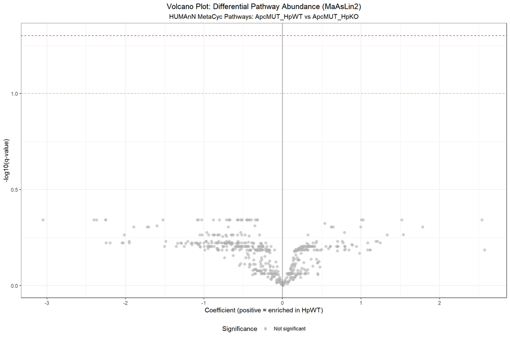

```r
# ------------------------------------------------------------------------------
# 火山图：展示差异通路
# ------------------------------------------------------------------------------

# 准备绘图数据（使用MaAsLin2结果）
humann_volcano_df <- humann_maaslin2_summary |>
  dplyr::mutate(
    neg_log10_q = -log10(qval),
    significance = case_when(
      qval < 0.05 & coef > 0 ~ "Enriched in HpWT (q<0.05)",
      qval < 0.05 & coef < 0 ~ "Depleted in HpWT (q<0.05)",
      qval < 0.1 ~ "Trending (q<0.1)",
      TRUE ~ "Not significant"
    ),
    # 简化通路名称用于标注
    pathway_short = stringr::str_trunc(pathway, 50)
  )

# 火山图
p3_1_humann_volcano <- ggplot(
  humann_volcano_df,
  aes(x = coef, y = neg_log10_q, color = significance)
) +
  geom_point(alpha = 0.6, size = 2) +
  geom_hline(yintercept = -log10(0.05), linetype = "dashed", color = "red") +
  geom_hline(yintercept = -log10(0.1), linetype = "dashed", color = "orange") +
  geom_vline(xintercept = 0, linetype = "solid", color = "grey50") +
  scale_color_manual(values = c(
    "Enriched in HpWT (q<0.05)" = "#E41A1C",
    "Depleted in HpWT (q<0.05)" = "#377EB8",
    "Trending (q<0.1)" = "#FF7F00",
    "Not significant" = "grey70"
  )) +
  # 标注Top差异通路
  ggrepel::geom_text_repel(
    data = humann_volcano_df |> dplyr::filter(qval < 0.2) |> head(10),
    aes(label = pathway_short),
    size = 2.5,
    max.overlaps = 15,
    box.padding = 0.5
  ) +
  labs(
    title = "Volcano Plot: Differential Pathway Abundance (MaAsLin2)",
    subtitle = "HUMAnN MetaCyc Pathways: ApcMUT_HpWT vs ApcMUT_HpKO",
    x = "Coefficient (positive = enriched in HpWT)",
    y = "-log10(q-value)",
    color = "Significance"
  ) +
  theme_bw() +
  theme(
    legend.position = "bottom",
    plot.title = element_text(hjust = 0.5),
    plot.subtitle = element_text(hjust = 0.5)
  )

print(p3_1_humann_volcano)
```

```r
ggsave(
  path_target("07_volcano_daa_humann_pathway.png"),
  p3_1_humann_volcano,
  width = 12, height = 8, dpi = 300
)
```

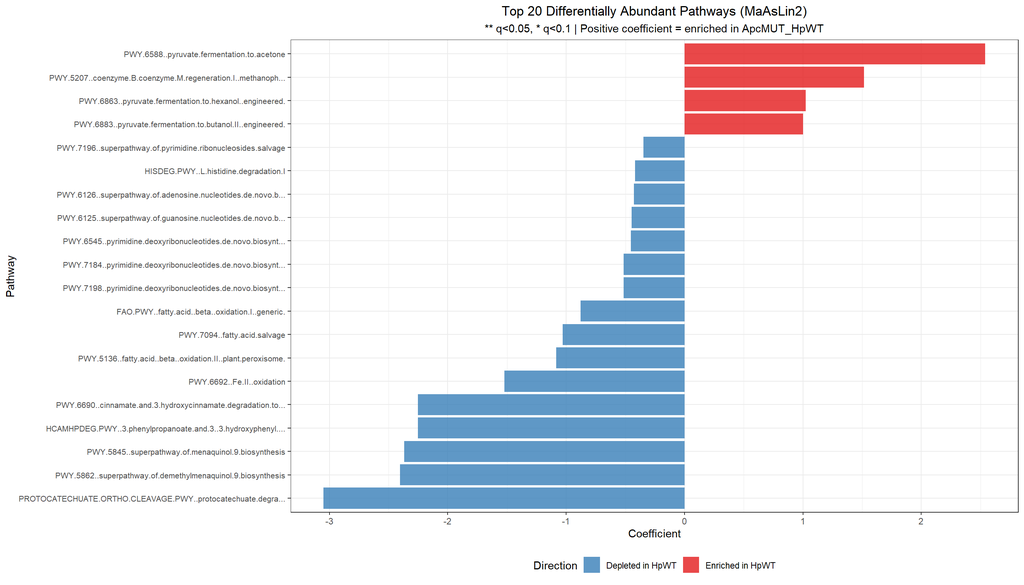

```r
# ------------------------------------------------------------------------------
# 条形图：展示Top差异通路的系数
# ------------------------------------------------------------------------------

# 选择Top 20通路（按q值）
humann_top20_for_plot <- humann_maaslin2_summary |>
  head(20) |>
  dplyr::mutate(
    pathway_short = stringr::str_trunc(pathway, 60),
    direction = ifelse(coef > 0, "Enriched in HpWT", "Depleted in HpWT"),
    sig_label = case_when(
      qval < 0.05 ~ "**",
      qval < 0.1 ~ "*",
      TRUE ~ ""
    )
  )

p3_2_humann_coef_bar <- ggplot(
  humann_top20_for_plot,
  aes(x = reorder(pathway_short, coef), y = coef, fill = direction)
) +
  geom_bar(stat = "identity", alpha = 0.8) +
  geom_text(aes(label = sig_label), hjust = ifelse(humann_top20_for_plot$coef > 0, -0.3, 1.3), size = 5) +
  coord_flip() +
  scale_fill_manual(values = c("Enriched in HpWT" = "#E41A1C", "Depleted in HpWT" = "#377EB8")) +
  labs(
    title = "Top 20 Differentially Abundant Pathways (MaAsLin2)",
    subtitle = "** q<0.05, * q<0.1 | Positive coefficient = enriched in ApcMUT_HpWT",
    x = "Pathway",
    y = "Coefficient",
    fill = "Direction"
  ) +
  theme_bw() +
  theme(
    axis.text.y = element_text(size = 8),
    legend.position = "bottom",
    plot.title = element_text(hjust = 0.5),
    plot.subtitle = element_text(hjust = 0.5)
  )

print(p3_2_humann_coef_bar)
```

```r
ggsave(
  path_target("08_barplot_top20_daa_humann_pathway.png"),
  p3_2_humann_coef_bar,
  width = 14, height = 8, dpi = 300
)
```

### 0.3.3 3.3 DAA结果小结

```r
cat("========================================\n")
cat("   通路差异丰度分析结果汇总 (DAA)\n")
```

```
   通路差异丰度分析结果汇总 (DAA)
```

```r
cat("========================================\n\n")
cat("【MaAsLin2结果】\n")
```

```
【MaAsLin2结果】
```

```r
cat("- 检测通路总数:", nrow(humann_maaslin2_summary), "\n")
```

```
- 检测通路总数: 618
```

```r
cat("- 显著差异 (q<0.05):", sum(humann_maaslin2_summary$qval < 0.05), "\n")
```

```
- 显著差异 (q<0.05): 0
```

```r
cat("- 趋势性差异 (q<0.1):", sum(humann_maaslin2_summary$qval < 0.1), "\n")
```

```
- 趋势性差异 (q<0.1): 0
```

```r
if (nrow(humann_significant_pathways) > 0) {
  cat("\n显著富集在HpWT的通路:\n")
  sig_enriched <- humann_significant_pathways |> dplyr::filter(coef > 0)
  if (nrow(sig_enriched) > 0) {
    print(sig_enriched |> head(5))
  } else {
    cat("  无\n")
  }

  cat("\n显著在HpWT中减少的通路:\n")
  sig_depleted <- humann_significant_pathways |> dplyr::filter(coef < 0)
  if (nrow(sig_depleted) > 0) {
    print(sig_depleted |> head(5))
  } else {
    cat("  无\n")
  }
}

cat("\n【生物学解读】\n")
```

```
【生物学解读】
```

```r
if (sum(humann_maaslin2_summary$qval < 0.05) > 0) {
  cat("发现了显著差异的代谢通路，这些通路可能：\n")
  cat("1. 直接参与CagA诱导的代谢重编程\n")
  cat("2. 反映特定细菌群落的功能变化\n")
  cat("3. 产生影响宿主免疫的代谢产物\n")
} else if (sum(humann_maaslin2_summary$qval < 0.1) > 0) {
  cat("虽然没有严格显著的通路(q<0.05)，但存在趋势性差异(q<0.1)。\n")
  cat("这可能反映了功能层面的细微变化，需要结合生物学背景解读。\n")
} else {
  cat("功能通路层面未发现显著差异。\n")
  cat("这支持\"功能冗余\"假说：不同物种可以执行相似的代谢功能，\n")
  cat("因此即使物种组成改变，整体功能潜力可能保持稳定。\n")
}
```

```
功能通路层面未发现显著差异。
这支持"功能冗余"假说：不同物种可以执行相似的代谢功能，
因此即使物种组成改变，整体功能潜力可能保持稳定。
```

## 0.4 Part 4: 驱动物种分析 (Driver Species Analysis)

**科学问题**：哪些微生物物种贡献了差异代谢通路？

这种”功能→物种”的反向追溯可以揭示： 1. 某个通路在不同组中是否由不同物种提供（功能替代） 2. 差异通路的变化是否由特定物种驱动

### 0.4.1 4.1 导入Stratified数据

```r
# ------------------------------------------------------------------------------
# 读取stratified pathway abundance数据
# 该数据包含每个通路按物种分解的丰度
# 格式：pathway|species → abundance
# ------------------------------------------------------------------------------

# 读取stratified数据
pathway_stratified <- fread(
  file.path(humann_data_dir, "humann4_pathabundance-step2-normalized_stratified.tsv"),
  header = TRUE
)

# 查看数据结构
cat("=== Stratified Pathway Data ===\n")
```

```
=== Stratified Pathway Data ===
```

```r
cat("维度:", nrow(pathway_stratified), "行 x", ncol(pathway_stratified), "列\n\n")
```

```
维度: 12641 行 x 34 列
```

```r
# 查看前几行（展示pathway|species格式）
head(pathway_stratified[, 1:4], 10)
```

```
                                # Pathway HUMAnN v4.0.0.alpha.1 ca01_Abundance
                                                         <char>          <num>
 1:          UNINTEGRATED|s__Acutalibacter_SGB43256.t__SGB43256        788.225
 2:             UNINTEGRATED|s__Acutalibacter_muris.t__SGB43254        389.956
 3:        UNINTEGRATED|s__Acutalibacter_sp_1XD8_33.t__SGB29419        399.875
 4:        UNINTEGRATED|s__Adlercreutzia_mucosicola.t__SGB33554          0.000
 5:             UNINTEGRATED|s__Adlercreutzia_muris.t__SGB33553          0.000
 6:          UNINTEGRATED|s__Akkermansia_muciniphila.t__SGB9226          0.000
 7:             UNINTEGRATED|s__Alistipes_finegoldii.t__SGB2301          0.000
 8:                    UNINTEGRATED|s__Alistipes_sp.t__SGB35892        350.686
 9:       UNINTEGRATED|s__Anaerotruncus_sp_1XD42_93.t__SGB43003        755.014
10: UNINTEGRATED|s__Atopobiaceae_bacterium_FL090493.t__SGB33580          0.000
    ca02_Abundance ca03_Abundance
             <num>          <num>
 1:        407.587       1379.150
 2:        358.154       1397.090
 3:        451.583        546.233
 4:          0.000          0.000
 5:          0.000          0.000
 6:          0.000          0.000
 7:          0.000          0.000
 8:       1781.770       1976.420
 9:        339.609       1288.270
10:          0.000          0.000
```

```r
# ------------------------------------------------------------------------------
# 解析stratified数据：分离pathway和species信息
# ------------------------------------------------------------------------------

# 获取第一列名称
first_col <- colnames(pathway_stratified)[1]

# 分离pathway和species
pathway_stratified_parsed <- pathway_stratified |>
  dplyr::mutate(
    # 原始ID
    original_id = get(first_col),
    # 分离pathway和species（以"|"分隔）
    pathway = stringr::str_extract(original_id, "^[^|]+"),
    species = stringr::str_extract(original_id, "(?<=\\|).+$")
  ) |>
  # 只保留有物种注释的行（排除总量行）
dplyr::filter(!is.na(species))

# 清理样本名
sample_cols <- base::setdiff(colnames(pathway_stratified_parsed), c(first_col, "original_id", "pathway", "species"))
colnames(pathway_stratified_parsed) <- gsub("_Abundance$", "", colnames(pathway_stratified_parsed))

# 更新样本列名
sample_cols <- gsub("_Abundance$", "", sample_cols)

cat("=== 解析后数据 ===\n")
```

```
=== 解析后数据 ===
```

```r
cat("Pathway-Species组合数:", nrow(pathway_stratified_parsed), "\n")
```

```
Pathway-Species组合数: 12641
```

```r
cat("唯一通路数:", length(unique(pathway_stratified_parsed$pathway)), "\n")
```

```
唯一通路数: 632
```

```r
cat("唯一物种数:", length(unique(pathway_stratified_parsed$species)), "\n")
```

```
唯一物种数: 321
```

### 0.4.2 4.2 筛选Top差异通路的物种贡献

```r
# ------------------------------------------------------------------------------
# 选择Top差异通路进行驱动物种分析
# 策略：选择MaAsLin2结果中q值最小的Top通路
# ------------------------------------------------------------------------------

# 选择Top 5差异通路
n_top_pathways <- 5
top_pathways <- humann_maaslin2_summary |>
  head(n_top_pathways) |>
  dplyr::pull(pathway)

cat("=== 选择的Top", n_top_pathways, "差异通路 ===\n")
```

```
=== 选择的Top 5 差异通路 ===
```

```r
for (i in seq_along(top_pathways)) {
  qval <- humann_maaslin2_summary$qval[i]
  coef <- humann_maaslin2_summary$coef[i]
  direction <- ifelse(coef > 0, "↑HpWT", "↓HpWT")
  cat(i, ".", stringr::str_trunc(top_pathways[i], 60),
      " (q=", round(qval, 3), ", ", direction, ")\n", sep = "")
}
```

```
1.FAO.PWY..fatty.acid..beta..oxidation.I..generic. (q=0.456, ↓HpWT)
2.HCAMHPDEG.PWY..3.phenylpropanoate.and.3..3.hydroxyphenyl.... (q=0.456, ↓HpWT)
3.HISDEG.PWY..L.histidine.degradation.I (q=0.456, ↓HpWT)
4.PROTOCATECHUATE.ORTHO.CLEAVAGE.PWY..protocatechuate.degra... (q=0.456, ↓HpWT)
5.PWY.5136..fatty.acid..beta..oxidation.II..plant.peroxisome. (q=0.456, ↓HpWT)
```

```r
# ------------------------------------------------------------------------------
# 提取Top通路的物种贡献数据
# ------------------------------------------------------------------------------

# 筛选Top通路的stratified数据
cat("=== 数据匹配诊断 ===\n")
```

```
=== 数据匹配诊断 ===
```

```r
cat("Top通路数量:", length(top_pathways), "\n")
```

```
Top通路数量: 5
```

```r
cat("Top通路示例:\n")
```

```
Top通路示例:
```

```r
print(head(top_pathways, 3))
```

```
[1] "FAO.PWY..fatty.acid..beta..oxidation.I..generic."
[2] "HCAMHPDEG.PWY..3.phenylpropanoate.and.3..3.hydroxyphenyl.propanoate.degradation.to.2.hydroxypentadienoate"
[3] "HISDEG.PWY..L.histidine.degradation.I"
```

```r
cat("\nstratified数据中的通路示例:\n")
```

```
stratified数据中的通路示例:
```

```r
print(head(unique(pathway_stratified_parsed$pathway), 3))
```

```
[1] "UNINTEGRATED"
[2] "1CMET2-PWY: folate transformations III (E. coli)"
[3] "3-HYDROXYPHENYLACETATE-DEGRADATION-PWY: 4-hydroxyphenylacetate degradation"
```

```r
top_pathway_stratified <- pathway_stratified_parsed |>
  dplyr::filter(pathway %in% top_pathways)

cat("\n匹配到的stratified行数:", nrow(top_pathway_stratified), "\n")
```

```
匹配到的stratified行数: 0
```

```r
# 获取核心比较组的样本
corepair_samples <- colnames(tse_humann_pathway_ca_corepair)

# 筛选样本并整理数据
# 注意：需要确保样本名匹配
available_samples <- base::intersect(corepair_samples, colnames(top_pathway_stratified))

cat("=== 物种贡献数据 ===\n")
```

```
=== 物种贡献数据 ===
```

```r
cat("核心比较组样本数:", length(corepair_samples), "\n")
```

```
核心比较组样本数: 9
```

```r
cat("stratified数据列名样本:", paste(head(base::setdiff(colnames(top_pathway_stratified), c("# Pathway", "original_id", "pathway", "species")), 3), collapse = ", "), "\n")
```

```
stratified数据列名样本: # Pathway HUMAnN v4.0.0.alpha.1, ca01, ca02
```

```r
cat("匹配样本数:", length(available_samples), "\n")
```

```
匹配样本数: 9
```

```r
cat("涉及Pathway-Species组合:", nrow(top_pathway_stratified), "\n")
```

```
涉及Pathway-Species组合: 0
```

```r
# ------------------------------------------------------------------------------
# 准备驱动物种分析数据
# 转换为长格式并添加分组信息
# ------------------------------------------------------------------------------

# 获取样本的分组信息
sample_groups <- data.frame(
  sample = colnames(tse_humann_pathway_ca_corepair),
  treatment_group = as.character(tse_humann_pathway_ca_corepair$treatment_group)
)

# 转换为长格式
if (length(available_samples) > 0 && nrow(top_pathway_stratified) > 0) {
  driver_data_long <- top_pathway_stratified |>
    dplyr::select(pathway, species, all_of(available_samples)) |>
    tidyr::pivot_longer(
      cols = all_of(available_samples),
      names_to = "sample",
      values_to = "abundance"
    ) |>
    # 添加分组信息
    dplyr::left_join(sample_groups, by = "sample") |>
    # 过滤掉NA的分组（非核心比较组样本）
    dplyr::filter(!is.na(treatment_group))
} else {
  # 创建空的driver_data_long以避免后续错误
  driver_data_long <- data.frame(
    pathway = character(),
    species = character(),
    sample = character(),
    abundance = numeric(),
    treatment_group = character()
  )
  cat("警告: 没有匹配的样本或stratified数据，创建空数据框\n")
}
cat("=== 长格式数据 ===\n")
```

```
=== 长格式数据 ===
```

```r
cat("总行数:", nrow(driver_data_long), "\n")
```

```
总行数: 0
```

```r
if (nrow(driver_data_long) > 0) {
  cat("唯一通路数:", length(unique(driver_data_long$pathway)), "\n")
  cat("唯一物种数:", length(unique(driver_data_long$species)), "\n")
  cat("分组分布:\n")
  print(table(driver_data_long$treatment_group))
} else {
  cat("警告: driver_data_long为空!\n")
}
```

### 0.4.3 4.3 计算各组的物种贡献比例

```r
# ------------------------------------------------------------------------------
# 计算每个通路中各物种的平均贡献
# ------------------------------------------------------------------------------

if (nrow(driver_data_long) > 0) {
  # 按通路、物种、分组计算平均丰度
  driver_summary <- driver_data_long |>
    dplyr::group_by(pathway, species, treatment_group) |>
    dplyr::summarise(
      mean_abundance = mean(abundance, na.rm = TRUE),
      .groups = "drop"
    ) |>
    # 计算每个通路在每组中的总丰度
    dplyr::group_by(pathway, treatment_group) |>
    dplyr::mutate(
      total_pathway_abundance = sum(mean_abundance),
      contribution_pct = ifelse(total_pathway_abundance > 0,
                                 mean_abundance / total_pathway_abundance * 100,
                                 0)
    ) |>
    dplyr::ungroup()

  # 筛选主要贡献物种（贡献>1%的物种）
  driver_summary_major <- driver_summary |>
    dplyr::filter(contribution_pct > 1)
} else {
  # 创建空的driver_summary
  driver_summary <- data.frame(
    pathway = character(),
    species = character(),
    treatment_group = character(),
    mean_abundance = numeric(),
    total_pathway_abundance = numeric(),
    contribution_pct = numeric()
  )
  driver_summary_major <- driver_summary
  cat("警告: driver_data_long为空，无法计算物种贡献\n")
}
cat("=== 物种贡献统计 ===\n")
```

```
=== 物种贡献统计 ===
```

```r
cat("所有物种贡献记录:", nrow(driver_summary), "\n")
```

```
所有物种贡献记录: 0
```

```r
cat("主要贡献物种 (>1%):", nrow(driver_summary_major), "\n")
```

```
主要贡献物种 (>1%): 0
```

### 0.4.4 4.4 驱动物种可视化

```r
# ------------------------------------------------------------------------------
# 热图：展示Top通路的物种贡献
# ------------------------------------------------------------------------------

# 检查driver_summary数据
cat("=== driver_summary 数据检查 ===\n")
```

```
=== driver_summary 数据检查 ===
```

```r
cat("总行数:", nrow(driver_summary), "\n")
```

```
总行数: 0
```

```r
cat("唯一通路:", length(unique(driver_summary$pathway)), "\n")
```

```
唯一通路: 0
```

```r
cat("唯一物种:", length(unique(driver_summary$species)), "\n\n")
```

```
唯一物种: 0
```

```r
# 准备热图数据：选择每个通路的Top 10贡献物种
driver_heatmap_data <- driver_summary |>
  # 先简化名称
  dplyr::mutate(
    species_short = stringr::str_replace(species, ".*s__", ""),
    species_short = stringr::str_trunc(species_short, 30),
    pathway_short = stringr::str_trunc(pathway, 40)
  ) |>
  # 按通路分组，选择Top 10
  dplyr::group_by(pathway_short, treatment_group) |>
  dplyr::slice_max(order_by = mean_abundance, n = 10, with_ties = FALSE) |>
  dplyr::ungroup()

cat("热图数据行数:", nrow(driver_heatmap_data), "\n")
```

```
热图数据行数: 0
```

```r
# 只有数据存在且facet变量有效时才绑图
n_unique_pathways <- length(unique(driver_heatmap_data$pathway_short[!is.na(driver_heatmap_data$pathway_short) & driver_heatmap_data$pathway_short != ""]))
cat("唯一pathway_short数量:", n_unique_pathways, "\n")
```

```
唯一pathway_short数量: 0
```

```r
if (nrow(driver_heatmap_data) > 0 && n_unique_pathways > 0) {
  # 创建热图
  p4_1_driver_heatmap <- ggplot(
    driver_heatmap_data,
    aes(x = treatment_group, y = species_short, fill = log10(mean_abundance + 1))
  ) +
    geom_tile(color = "white", linewidth = 0.5) +
    facet_wrap(~ pathway_short, scales = "free_y", ncol = 2) +
    scale_fill_viridis_c(option = "plasma", name = "log10(Abundance+1)") +
    labs(
      title = "Species Contributions to Top Differential Pathways",
      subtitle = "Top 10 contributing species per pathway",
      x = "Treatment Group",
      y = "Species"
    ) +
    theme_minimal() +
    theme(
      axis.text.y = element_text(size = 7),
      axis.text.x = element_text(angle = 45, hjust = 1),
      strip.text = element_text(size = 8, face = "bold"),
      legend.position = "right"
    )

  print(p4_1_driver_heatmap)

  ggsave(
    path_target("09_driver_species_heatmap.png"),
    p4_1_driver_heatmap,
    width = 14, height = 10, dpi = 300
  )
} else {
  cat("警告: 热图数据为空，跳过绑图\n")
}
```

```r
# ------------------------------------------------------------------------------
# 堆叠条形图：展示物种贡献比例
# ------------------------------------------------------------------------------

if (nrow(driver_summary) > 0) {
  # 选择每个通路的Top 5贡献物种，其余归为"Other"
  driver_bar_data <- driver_summary |>
    dplyr::mutate(
      pathway_short = stringr::str_trunc(pathway, 50)
    ) |>
    dplyr::group_by(pathway_short, treatment_group) |>
    dplyr::mutate(
      rank = rank(-mean_abundance, ties.method = "first"),
      species_grouped = ifelse(rank <= 5, species, "Other")
    ) |>
    dplyr::group_by(pathway_short, treatment_group, species_grouped) |>
    dplyr::summarise(
      mean_abundance = sum(mean_abundance),
      .groups = "drop"
    ) |>
    # 简化名称
    dplyr::mutate(
      species_short = ifelse(
        species_grouped == "Other",
        "Other",
        stringr::str_replace(species_grouped, ".*s__", "")
      )
    )

  cat("堆叠条形图数据行数:", nrow(driver_bar_data), "\n")

  if (nrow(driver_bar_data) > 0 && length(unique(driver_bar_data$pathway_short)) > 0) {
    # 使用colorRampPalette创建足够的颜色
    n_species <- length(unique(driver_bar_data$species_short))
    if (n_species <= 12) {
      species_colors <- RColorBrewer::brewer.pal(max(3, n_species), "Set3")
    } else {
      species_colors <- colorRampPalette(RColorBrewer::brewer.pal(12, "Set3"))(n_species)
    }
    names(species_colors) <- unique(driver_bar_data$species_short)

    # 堆叠条形图
    p4_2_driver_bar <- ggplot(
      driver_bar_data,
      aes(x = treatment_group, y = mean_abundance, fill = species_short)
    ) +
      geom_bar(stat = "identity", position = "stack") +
      facet_wrap(~ pathway_short, scales = "free_y", ncol = 2) +
      scale_fill_manual(values = species_colors, name = "Species") +
      labs(
        title = "Species Contributions to Top Differential Pathways",
        subtitle = "Stacked bar showing top 5 species + Other",
        x = "Treatment Group",
        y = "Mean Abundance (CPM)"
      ) +
      theme_bw() +
      theme(
        axis.text.x = element_text(angle = 45, hjust = 1),
        strip.text = element_text(size = 9, face = "bold"),
        legend.position = "right"
      )

    print(p4_2_driver_bar)

    ggsave(
      path_target("10_driver_species_barplot.png"),
      p4_2_driver_bar,
      width = 14, height = 12, dpi = 300
    )
  } else {
    cat("警告: 堆叠条形图数据为空，跳过绑图\n")
  }
} else {
  cat("警告: driver_summary为空，跳过堆叠条形图\n")
}
```

### 0.4.5 4.5 识别差异驱动物种

```r
# ------------------------------------------------------------------------------
# 识别在两组间贡献差异最大的物种
# 计算每个物种在每个通路中的贡献变化
# ------------------------------------------------------------------------------

# 宽格式：比较两组间的物种贡献
driver_comparison <- driver_summary |>
  dplyr::select(pathway, species, treatment_group, mean_abundance) |>
  tidyr::pivot_wider(
    names_from = treatment_group,
    values_from = mean_abundance,
    values_fill = 0
  )

# 计算贡献差异（如果两组都存在）
if ("ApcMUT_HpWT" %in% colnames(driver_comparison) & "ApcMUT_HpKO" %in% colnames(driver_comparison)) {
  driver_comparison <- driver_comparison |>
    dplyr::mutate(
      diff_abundance = ApcMUT_HpWT - ApcMUT_HpKO,
      fold_change = ifelse(ApcMUT_HpKO > 0, ApcMUT_HpWT / ApcMUT_HpKO, NA),
      log2FC = log2(fold_change)
    ) |>
    dplyr::arrange(desc(abs(diff_abundance)))

  cat("=== Top 10 差异贡献物种 (按绝对差异) ===\n")
  top_driver_species <- driver_comparison |>
    head(10) |>
    dplyr::mutate(
      species_short = stringr::str_replace(species, ".*s__", ""),
      pathway_short = stringr::str_trunc(pathway, 40)
    ) |>
    dplyr::select(pathway_short, species_short, ApcMUT_HpWT, ApcMUT_HpKO, diff_abundance)

  print(top_driver_species)
}
```

```r
# ------------------------------------------------------------------------------
# 保存驱动物种分析结果
# ------------------------------------------------------------------------------

# 保存完整比较结果
if (exists("driver_comparison") && nrow(driver_comparison) > 0) {
  driver_results_full <- driver_comparison |>
    dplyr::mutate(
      species_short = stringr::str_replace(species, ".*s__", ""),
      pathway_short = stringr::str_trunc(pathway, 60)
    )

  # 根据是否有diff_abundance列决定排序方式
  if ("diff_abundance" %in% colnames(driver_results_full)) {
    driver_results_full <- driver_results_full |>
      dplyr::arrange(pathway, desc(abs(diff_abundance)))
  } else {
    # 如果没有diff_abundance，按pathway和species排序
    driver_results_full <- driver_results_full |>
      dplyr::arrange(pathway, species)
    cat("注意: 未找到diff_abundance列，按pathway和species排序\n")
  }

  write.csv(
    driver_results_full,
    file = path_target("11_driver_species_analysis_full.csv"),
    row.names = FALSE
  )

  cat("✓ 驱动物种分析结果已保存\n")
} else {
  cat("警告: driver_comparison为空，跳过保存\n")
}
```

### 0.4.6 4.6 扩展可视化：物种-通路贡献网络

```r
# ------------------------------------------------------------------------------
# 点图：展示物种在不同通路中的贡献差异
# X轴：贡献差异，Y轴：物种，颜色：通路，大小：平均贡献
# ------------------------------------------------------------------------------

if (exists("driver_comparison") && nrow(driver_comparison) > 0 &&
    "ApcMUT_HpWT" %in% colnames(driver_comparison) &&
    "ApcMUT_HpKO" %in% colnames(driver_comparison) &&
    "diff_abundance" %in% colnames(driver_comparison)) {

  # 准备点图数据
  driver_dotplot_data <- driver_comparison |>
    dplyr::mutate(
      species_short = stringr::str_replace(species, ".*s__", ""),
      pathway_short = stringr::str_trunc(pathway, 35),
      avg_abundance = (ApcMUT_HpWT + ApcMUT_HpKO) / 2
    ) |>
    # 筛选有一定贡献的物种
    dplyr::filter(avg_abundance > 1) |>
    # 按差异绝对值排序
    dplyr::arrange(desc(abs(diff_abundance)))

  cat("点图数据行数:", nrow(driver_dotplot_data), "\n")

  if (nrow(driver_dotplot_data) > 0) {
    # 获取top50数据
    plot_data_top50 <- driver_dotplot_data |> head(50)

    # 创建足够的颜色用于通路
    n_pathways <- length(unique(plot_data_top50$pathway_short))
    if (n_pathways <= 8) {
      pathway_colors <- RColorBrewer::brewer.pal(max(3, n_pathways), "Set2")
    } else {
      pathway_colors <- colorRampPalette(RColorBrewer::brewer.pal(8, "Set2"))(n_pathways)
    }
    names(pathway_colors) <- unique(plot_data_top50$pathway_short)

    # 创建点图
    p4_3_driver_dotplot <- ggplot(
      plot_data_top50,
      aes(x = diff_abundance, y = reorder(species_short, abs(diff_abundance)))
    ) +
      geom_vline(xintercept = 0, linetype = "dashed", color = "grey50") +
      geom_point(aes(color = pathway_short, size = avg_abundance), alpha = 0.7) +
      scale_color_manual(values = pathway_colors, name = "Pathway") +
      scale_size_continuous(name = "Avg Abundance", range = c(2, 8)) +
      labs(
        title = "Species Contribution Differences Across Pathways",
        subtitle = "Positive = higher contribution in HpWT | Top 50 species-pathway combinations",
        x = "Contribution Difference (HpWT - HpKO)",
        y = "Species",
        color = "Pathway"
      ) +
      theme_bw() +
      theme(
        axis.text.y = element_text(size = 8),
        legend.position = "right",
        legend.box = "vertical"
      )

    print(p4_3_driver_dotplot)

    ggsave(
      path_target("12_driver_species_dotplot.png"),
      p4_3_driver_dotplot,
      width = 12, height = 10, dpi = 300
    )
  } else {
    cat("点图数据为空，跳过\n")
  }
} else {
  cat("driver_comparison数据不可用，跳过点图\n")
}
```

```
driver_comparison数据不可用，跳过点图
```

```r
# ------------------------------------------------------------------------------
# 配对条形图：直接比较两组中各物种的贡献
# ------------------------------------------------------------------------------

if (nrow(driver_summary) > 0) {
  # 选择贡献最大的Top 15物种（跨所有通路）
  top_species <- driver_summary |>
    dplyr::group_by(species) |>
    dplyr::summarise(total_abundance = sum(mean_abundance), .groups = "drop") |>
    dplyr::slice_max(order_by = total_abundance, n = 15) |>
    dplyr::pull(species)

  # 筛选数据
  driver_paired_data <- driver_summary |>
    dplyr::filter(species %in% top_species) |>
    dplyr::mutate(
      species_short = stringr::str_replace(species, ".*s__", ""),
      pathway_short = stringr::str_trunc(pathway, 30)
    )

  cat("配对条形图数据行数:", nrow(driver_paired_data), "\n")

  if (nrow(driver_paired_data) > 0 && length(unique(driver_paired_data$pathway_short)) > 0) {
    # 配对条形图
    p4_4_paired_bar <- ggplot(
      driver_paired_data,
      aes(x = species_short, y = mean_abundance, fill = treatment_group)
    ) +
      geom_bar(stat = "identity", position = position_dodge(width = 0.8), width = 0.7) +
      facet_wrap(~ pathway_short, scales = "free_y", ncol = 2) +
      scale_fill_manual(
        values = c("ApcMUT_HpWT" = "#E41A1C", "ApcMUT_HpKO" = "#377EB8"),
        name = "Treatment"
      ) +
      labs(
        title = "Species Contributions: HpWT vs HpKO",
        subtitle = "Top 15 contributing species across differential pathways",
        x = "Species",
        y = "Mean Abundance (CPM)"
      ) +
      theme_bw() +
      theme(
        axis.text.x = element_text(angle = 45, hjust = 1, size = 7),
        strip.text = element_text(size = 8, face = "bold"),
        legend.position = "top"
      )

    print(p4_4_paired_bar)

    ggsave(
      path_target("13_driver_species_paired_bar.png"),
      p4_4_paired_bar,
      width = 14, height = 10, dpi = 300
    )
  } else {
    cat("配对条形图数据为空，跳过\n")
  }
} else {
  cat("driver_summary为空，跳过配对条形图\n")
}
```

```
driver_summary为空，跳过配对条形图
```

```r
# ------------------------------------------------------------------------------
# 贡献比例热图：展示物种在各通路中的贡献百分比
# ------------------------------------------------------------------------------

if (nrow(driver_summary) > 0 && "contribution_pct" %in% colnames(driver_summary)) {
  # 准备百分比热图数据
  driver_pct_heatmap <- driver_summary |>
    dplyr::filter(contribution_pct > 2) |>  # 筛选贡献>2%的
    dplyr::mutate(
      species_short = stringr::str_replace(species, ".*s__", ""),
      species_short = stringr::str_trunc(species_short, 25),
      pathway_short = stringr::str_trunc(pathway, 35)
    )

  cat("百分比热图数据行数:", nrow(driver_pct_heatmap), "\n")

  if (nrow(driver_pct_heatmap) > 0 && length(unique(driver_pct_heatmap$pathway_short)) > 0) {
    # 百分比热图
    p4_5_pct_heatmap <- ggplot(
      driver_pct_heatmap,
      aes(x = treatment_group, y = reorder(species_short, contribution_pct), fill = contribution_pct)
    ) +
      geom_tile(color = "white", linewidth = 0.3) +
      geom_text(aes(label = round(contribution_pct, 1)), size = 2.5, color = "black") +
      facet_wrap(~ pathway_short, scales = "free_y", ncol = 2) +
      scale_fill_gradient(low = "#FFF5F0", high = "#A50F15", name = "Contribution %") +
      labs(
        title = "Species Contribution Percentage to Each Pathway",
        subtitle = "Only species contributing >2% shown | Numbers indicate contribution %",
        x = "Treatment Group",
        y = "Species"
      ) +
      theme_minimal() +
      theme(
        axis.text.y = element_text(size = 7),
        axis.text.x = element_text(angle = 45, hjust = 1),
        strip.text = element_text(size = 8, face = "bold"),
        legend.position = "right"
      )

    print(p4_5_pct_heatmap)

    ggsave(
      path_target("14_driver_contribution_pct_heatmap.png"),
      p4_5_pct_heatmap,
      width = 12, height = 10, dpi = 300
    )
  } else {
    cat("百分比热图数据为空，跳过\n")
  }
} else {
  cat("driver_summary不可用或缺少contribution_pct列，跳过百分比热图\n")
}
```

```
driver_summary不可用或缺少contribution_pct列，跳过百分比热图
```

```r
# ------------------------------------------------------------------------------
# 关键物种档案：展示Top驱动物种在所有通路中的贡献
# ------------------------------------------------------------------------------

if (exists("driver_comparison") && nrow(driver_comparison) > 0 && nrow(driver_summary) > 0 &&
    "diff_abundance" %in% colnames(driver_comparison)) {
  # 识别关键驱动物种（在多个通路中贡献变化大的物种）
  key_species <- driver_comparison |>
    dplyr::group_by(species) |>
    dplyr::summarise(
      n_pathways = n(),
      total_diff = sum(abs(diff_abundance)),
      mean_diff = mean(diff_abundance),
      .groups = "drop"
    ) |>
    dplyr::slice_max(order_by = total_diff, n = 8) |>
    dplyr::pull(species)

  # 筛选关键物种数据
  key_species_data <- driver_summary |>
    dplyr::filter(species %in% key_species) |>
    dplyr::mutate(
      species_short = stringr::str_replace(species, ".*s__", ""),
      pathway_short = stringr::str_trunc(pathway, 40)
    )

  cat("关键物种数据行数:", nrow(key_species_data), "\n")

  if (nrow(key_species_data) > 0 && length(unique(key_species_data$species_short)) > 0) {
    # 关键物种条形图
    p4_6_key_species <- ggplot(
      key_species_data,
      aes(x = pathway_short, y = mean_abundance, fill = treatment_group)
    ) +
      geom_bar(stat = "identity", position = position_dodge(width = 0.8), width = 0.7) +
      facet_wrap(~ species_short, scales = "free", ncol = 2) +
      scale_fill_manual(
        values = c("ApcMUT_HpWT" = "#D73027", "ApcMUT_HpKO" = "#4575B4"),
        name = "Treatment"
      ) +
      labs(
        title = "Key Driver Species: Contribution Profiles Across Pathways",
        subtitle = "Top 8 species with largest total contribution differences",
        x = "Pathway",
        y = "Mean Abundance (CPM)"
      ) +
      theme_bw() +
      theme(
        axis.text.x = element_text(angle = 45, hjust = 1, size = 7),
        strip.text = element_text(size = 9, face = "bold"),
        legend.position = "top"
      )

    print(p4_6_key_species)

    ggsave(
      path_target("15_key_driver_species_profile.png"),
      p4_6_key_species,
      width = 14, height = 8, dpi = 300
    )
  } else {
    cat("关键物种数据为空，跳过\n")
  }
} else {
  cat("数据不可用，跳过关键物种档案图\n")
}
```

```
数据不可用，跳过关键物种档案图
```

### 0.4.7 4.7 驱动物种分析小结

```r
cat("========================================\n")
cat("   驱动物种分析结果汇总\n")
```

```
   驱动物种分析结果汇总
```

```r
cat("========================================\n\n")
cat("【分析范围】\n")
```

```
【分析范围】
```

```r
cat("- 分析通路数:", n_top_pathways, "\n")
```

```
- 分析通路数: 5
```

```r
cat("- 涉及物种数:", length(unique(driver_summary$species)), "\n\n")
```

```
- 涉及物种数: 0
```

```r
cat("【主要发现】\n")
```

```
【主要发现】
```

```r
if (exists("driver_comparison") && nrow(driver_comparison) > 0 &&
    "diff_abundance" %in% colnames(driver_comparison)) {
  # 找出贡献变化最大的物种-通路组合
  top_changes <- driver_comparison |>
    dplyr::slice_max(order_by = abs(diff_abundance), n = 3)

  cat("贡献变化最大的物种-通路组合:\n")
  for (i in 1:min(3, nrow(top_changes))) {
    species_name <- stringr::str_replace(top_changes$species[i], ".*s__", "")
    pathway_name <- stringr::str_trunc(top_changes$pathway[i], 40)
    diff <- round(top_changes$diff_abundance[i], 2)
    direction <- ifelse(diff > 0, "在HpWT中增加", "在HpWT中减少")
    cat("  ", i, ". ", species_name, "\n",
        "     通路: ", pathway_name, "\n",
        "     变化: ", direction, " (Δ=", diff, ")\n\n", sep = "")
  }
} else {
  cat("差异数据不完整，无法展示主要发现\n")
}
```

```
差异数据不完整，无法展示主要发现
```

```r
cat("【生物学解读】\n")
```

```
【生物学解读】
```

```r
cat("驱动物种分析揭示了功能变化的微生物学基础：\n")
```

```
驱动物种分析揭示了功能变化的微生物学基础：
```

```r
cat("1. 如果同一通路由不同物种主导 → 功能替代/补偿\n")
```

```
1. 如果同一通路由不同物种主导 → 功能替代/补偿
```

```r
cat("2. 如果特定物种在多个通路中贡献变化 → 关键驱动物种\n")
```

```
2. 如果特定物种在多个通路中贡献变化 → 关键驱动物种
```

```r
cat("3. 结合01文档的物种差异结果 → 验证因果关系\n")
```

```
3. 结合01文档的物种差异结果 → 验证因果关系
```

# 1 Part 5: 基因家族(KO)差异分析

根据HUMAnN4分析协议：当通路水平分析未发现显著差异时，应转向更精细的基因家族(KO)水平分析。通路由多个基因组成，整体变化可能不明显，但关键限速酶或毒力基因可能显示显著差异。

## 1.1 5.1 导入KO基因家族数据

```r
# ------------------------------------------------------------------------------
# 导入KO基因家族数据（unstratified用于差异分析）
# ------------------------------------------------------------------------------

ko_unstratified_file <- here::here(
  "data/00-raw/d02_functional_profiling/humann4",
  "humann4_genefamilies-step3-KO_unstratified.tsv"
)

ko_unstratified <- read.delim(ko_unstratified_file, header = TRUE, sep = "\t")

cat("=== KO基因家族数据概览 ===\n")
```

```
=== KO基因家族数据概览 ===
```

```r
cat("文件:", basename(ko_unstratified_file), "\n")
```

```
文件: humann4_genefamilies-step3-KO_unstratified.tsv
```

```r
cat("KO数量:", nrow(ko_unstratified), "\n")
```

```
KO数量: 6107
```

```r
cat("样本数:", ncol(ko_unstratified) - 1, "\n")
```

```
样本数: 33
```

```r
# 查看前几行
head(ko_unstratified[, 1:5], 3)
```

```
  X..Gene.Family.HUMAnN.v4.0.0.alpha.1.Adjusted.CPMs         ca01         ca02
1                                          UNGROUPED 9.999370e+05 9.999561e+05
2                                             K00002 1.040730e-03 0.000000e+00
3                                             K00003 4.551858e-03 2.777028e-03
         ca03         ca04
1 9.99912e+05 9.999037e+05
2 0.00000e+00 4.370280e-03
3 4.92363e-03 2.593900e-03
```

```r
# ------------------------------------------------------------------------------
# 创建KO的TreeSummarizedExperiment对象
# ------------------------------------------------------------------------------

# 获取第一列名称（KO ID列）
ko_id_col <- colnames(ko_unstratified)[1]

# 设置行名
ko_matrix <- ko_unstratified
rownames(ko_matrix) <- ko_matrix[[ko_id_col]]
ko_matrix <- ko_matrix[, -1]  # 移除ID列

# 清理列名（移除_Abundance后缀）
colnames(ko_matrix) <- gsub("_Abundance$", "", colnames(ko_matrix))

# 转换为数值矩阵
ko_matrix <- as.matrix(ko_matrix)
mode(ko_matrix) <- "numeric"

cat("KO矩阵维度:", dim(ko_matrix), "\n")
```

```
KO矩阵维度: 6107 33
```

```r
cat("样本名示例:", paste(head(colnames(ko_matrix), 3), collapse = ", "), "\n")
```

```
样本名示例: ca01, ca02, ca03
```

```r
# 移除UNMAPPED和UNGROUPED
ko_to_remove <- c("UNMAPPED", "UNGROUPED")
ko_matrix_filtered <- ko_matrix[!rownames(ko_matrix) %in% ko_to_remove, ]

cat("移除UNMAPPED/UNGROUPED后KO数:", nrow(ko_matrix_filtered), "\n")
```

```
移除UNMAPPED/UNGROUPED后KO数: 6106
```

```r
# 移除全零行
ko_row_sums <- rowSums(ko_matrix_filtered)
ko_matrix_filtered <- ko_matrix_filtered[ko_row_sums > 0, ]

cat("移除全零行后KO数:", nrow(ko_matrix_filtered), "\n")
```

```
移除全零行后KO数: 6106
```

```r
# ------------------------------------------------------------------------------
# 创建TSE对象
# ------------------------------------------------------------------------------

# 直接从项目通用的 metadata 文件读取（不依赖 01qmd）
sample_metadata_ko <- readxl::read_xlsx(
  here::here("data", "metadata", "pc047-metadata.xlsx")
) |>
  as.data.frame()
rownames(sample_metadata_ko) <- sample_metadata_ko$sample_id

cat("元数据维度:", nrow(sample_metadata_ko), "x", ncol(sample_metadata_ko), "\n")
```

```
元数据维度: 33 x 12
```

```r
cat("元数据列名:", paste(head(colnames(sample_metadata_ko), 10), collapse = ", "), "...\n")
```

```
元数据列名: sample_id, mouse_id, genotype, infection, cagA_status, treatment_group, source_organ, Genotype_raw, Infection_raw, SampleID_raw ...
```

```r
# 筛选样本元数据
ko_samples <- colnames(ko_matrix_filtered)

cat("KO数据样本数:", length(ko_samples), "\n")
```

```
KO数据样本数: 33
```

```r
cat("元数据样本数:", nrow(sample_metadata_ko), "\n")
```

```
元数据样本数: 33
```

```r
# 找到共同样本
common_ko_samples <- base::intersect(ko_samples, sample_metadata_ko$sample_id)
cat("共同样本数:", length(common_ko_samples), "\n")
```

```
共同样本数: 33
```

```r
# 更新KO矩阵只保留共同样本
ko_matrix_filtered <- ko_matrix_filtered[, common_ko_samples, drop = FALSE]

# 筛选元数据
ko_sample_data <- sample_metadata_ko |>
  dplyr::filter(sample_id %in% common_ko_samples) |>
  dplyr::distinct(sample_id, .keep_all = TRUE)  # 去重

# 确保顺序一致
ko_sample_data <- ko_sample_data[match(common_ko_samples, ko_sample_data$sample_id), ]
rownames(ko_sample_data) <- ko_sample_data$sample_id

cat("最终样本数:", nrow(ko_sample_data), "\n")
```

```
最终样本数: 33
```

```r
# 创建行数据（KO注释）
ko_row_data <- data.frame(
  ko_id = rownames(ko_matrix_filtered),
  row.names = rownames(ko_matrix_filtered)
)

# 创建TSE
tse_ko <- TreeSummarizedExperiment(
  assays = list(counts = ko_matrix_filtered),
  colData = DataFrame(ko_sample_data),
  rowData = DataFrame(ko_row_data)
)

cat("=== KO TSE对象创建完成 ===\n")
```

```
=== KO TSE对象创建完成 ===
```

```r
cat("KO数量:", nrow(tse_ko), "\n")
```

```
KO数量: 6106
```

```r
cat("样本数:", ncol(tse_ko), "\n")
```

```
样本数: 33
```

```r
print(table(colData(tse_ko)$treatment_group))
```

```
ApcMUT_Ctrl ApcMUT_HpKO ApcMUT_HpWT  ApcWT_Ctrl  ApcWT_HpKO  ApcWT_HpWT
          5           4           5           9           5           5
```

## 1.2 5.2 KO数据标准化

```r
# ------------------------------------------------------------------------------
# CPM标准化（与Pathway分析一致）
# ------------------------------------------------------------------------------

# 计算CPM
ko_counts <- assay(tse_ko, "counts")
ko_lib_sizes <- colSums(ko_counts)
ko_cpm <- sweep(ko_counts, 2, ko_lib_sizes, "/") * 1e6

# 添加CPM assay
assay(tse_ko, "cpm") <- ko_cpm

cat("=== CPM标准化完成 ===\n")
```

```
=== CPM标准化完成 ===
```

```r
cat("CPM范围:", round(min(ko_cpm), 2), "-", round(max(ko_cpm), 2), "\n")
```

```
CPM范围: 0 - 65051.73
```

```r
cat("CPM中位数:", round(median(ko_cpm), 2), "\n")
```

```
CPM中位数: 11.51
```

```r
# 保存完整TSE
saveRDS(tse_ko, path_target("tse_humann_ko.rds"))
```

## 1.3 5.3 筛选核心比较组样本

```r
# ------------------------------------------------------------------------------
# 筛选核心比较组：ApcMUT_HpWT vs ApcMUT_HpKO
# ------------------------------------------------------------------------------

tse_ko_corepair <- tse_ko[, tse_ko$treatment_group %in% c("ApcMUT_HpWT", "ApcMUT_HpKO")]

cat("=== 核心比较组筛选 ===\n")
```

```
=== 核心比较组筛选 ===
```

```r
cat("筛选后样本数:", ncol(tse_ko_corepair), "\n")
```

```
筛选后样本数: 9
```

```r
print(table(colData(tse_ko_corepair)$treatment_group))
```

```
ApcMUT_HpKO ApcMUT_HpWT
          4           5
```

```r
# 移除低丰度KO（至少在20%样本中检测到）
ko_prevalence <- rowSums(assay(tse_ko_corepair, "counts") > 0) / ncol(tse_ko_corepair)
ko_prevalent <- ko_prevalence >= 0.2

tse_ko_corepair <- tse_ko_corepair[ko_prevalent, ]

cat("\n筛选后KO数（prevalence >= 20%）:", nrow(tse_ko_corepair), "\n")
```

```
筛选后KO数（prevalence >= 20%）: 3947
```

## 1.4 5.4 MaAsLin2差异分析

```r
# ------------------------------------------------------------------------------
# MaAsLin2差异分析 - KO水平
# 使用CPM数据，LOG转换，与Pathway分析一致
# ------------------------------------------------------------------------------



# 准备输入数据
ko_cpm_corepair <- as.data.frame(t(assay(tse_ko_corepair, "cpm")))
ko_metadata_corepair <- as.data.frame(colData(tse_ko_corepair))

# 设置参考组
ko_metadata_corepair$treatment_group <- factor(
  ko_metadata_corepair$treatment_group,
  levels = c("ApcMUT_HpKO", "ApcMUT_HpWT")  # HpKO为参考组
)

# 输出目录
maaslin2_ko_output <- path_target("maaslin2_ko_results")

cat("=== MaAsLin2 KO分析开始 ===\n")
```

```
=== MaAsLin2 KO分析开始 ===
```

```r
cat("输入KO数:", ncol(ko_cpm_corepair), "\n")
```

```
输入KO数: 3947
```

```r
cat("输入样本数:", nrow(ko_cpm_corepair), "\n")
```

```
输入样本数: 9
```

```r
# 运行MaAsLin2
maaslin2_ko_fit <- Maaslin2(
  input_data = ko_cpm_corepair,
  input_metadata = ko_metadata_corepair,
  output = maaslin2_ko_output,
  fixed_effects = c("treatment_group"),
  reference = c("treatment_group,ApcMUT_HpKO"),
  normalization = "NONE",  # 已经是CPM
  transform = "LOG",
  analysis_method = "LM",
  max_significance = 0.25,
  min_abundance = 0,
  min_prevalence = 0,
  plot_heatmap = FALSE,
  plot_scatter = FALSE,
  cores = 1
)
```

[output not shown]

[output cut: 3919 more lines]

[output not shown]

```r
cat("=== MaAsLin2 KO分析完成 ===\n")
```

```
=== MaAsLin2 KO分析完成 ===
```

```r
# ------------------------------------------------------------------------------
# 汇总MaAsLin2 KO分析结果
# ------------------------------------------------------------------------------

# 读取结果
ko_results_file <- file.path(maaslin2_ko_output, "all_results.tsv")
ko_maaslin2_results <- read.delim(ko_results_file, header = TRUE)

cat("=== MaAsLin2 KO结果汇总 ===\n")
```

```
=== MaAsLin2 KO结果汇总 ===
```

```r
cat("总检测KO数:", nrow(ko_maaslin2_results), "\n")
```

```
总检测KO数: 3947
```

```r
# 统计显著性
ko_sig_005 <- sum(ko_maaslin2_results$qval < 0.05, na.rm = TRUE)
ko_sig_010 <- sum(ko_maaslin2_results$qval < 0.10, na.rm = TRUE)
ko_sig_025 <- sum(ko_maaslin2_results$qval < 0.25, na.rm = TRUE)

cat("\n显著KO数量:\n")
```

```
显著KO数量:
```

```r
cat("  q < 0.05:", ko_sig_005, "\n")
```

```
  q < 0.05: 0
```

```r
cat("  q < 0.10:", ko_sig_010, "\n")
```

```
  q < 0.10: 0
```

```r
cat("  q < 0.25:", ko_sig_025, "\n")
```

```
  q < 0.25: 0
```

```r
# 按方向统计
if (ko_sig_025 > 0) {
  ko_sig_results <- ko_maaslin2_results |>
    dplyr::filter(qval < 0.25)

  ko_up_in_hpwt <- sum(ko_sig_results$coef > 0, na.rm = TRUE)
  ko_down_in_hpwt <- sum(ko_sig_results$coef < 0, na.rm = TRUE)

  cat("\n差异方向 (q < 0.25):\n")
  cat("  在HpWT中升高:", ko_up_in_hpwt, "\n")
  cat("  在HpWT中降低:", ko_down_in_hpwt, "\n")
}

# 显示Top结果
cat("\n=== Top 15 差异KO (按q值排序) ===\n")
```

```
=== Top 15 差异KO (按q值排序) ===
```

```r
ko_top_results <- ko_maaslin2_results |>
  dplyr::arrange(qval) |>
  head(15) |>
  dplyr::select(feature, coef, stderr, pval, qval)

print(ko_top_results)
```

```
   feature       coef    stderr       pval      qval
1   K00006 -0.6194996 0.4967639 0.25247724 0.6603161
2   K00008 -0.3656867 0.2045892 0.11701865 0.6603161
3   K00018  1.1711967 0.7842429 0.17896961 0.6603161
4   K00019 -1.0178872 0.4582083 0.06174492 0.6603161
5   K00020 -0.4758614 0.3422489 0.20701249 0.6603161
6   K00022 -1.1587900 0.6247630 0.10602271 0.6603161
7   K00024 -0.6207854 0.2751872 0.05868815 0.6603161
8   K00027  0.9837937 0.3666254 0.03138539 0.6603161
9   K00029 -0.8580590 0.4514350 0.09909861 0.6603161
10  K00033 -1.4714672 0.7240436 0.08163633 0.6603161
11  K00036 -0.5207456 0.2058589 0.03925449 0.6603161
12  K00046  0.3479340 0.2216652 0.16049000 0.6603161
13  K00053 -0.3929655 0.2734656 0.19387532 0.6603161
14  K00057 -0.6978932 0.5084092 0.21220646 0.6603161
15  K00058 -0.2975097 0.2091230 0.19783424 0.6603161
```

## 1.5 5.5 KO差异结果可视化

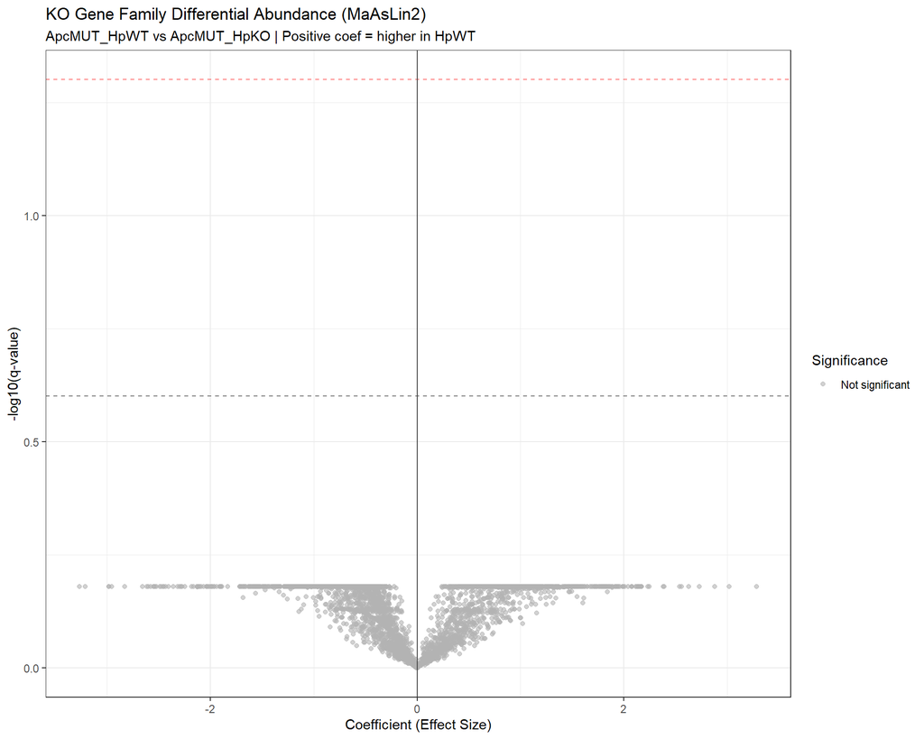

```r
# ------------------------------------------------------------------------------
# 火山图：KO差异分析结果
# ------------------------------------------------------------------------------

# 准备火山图数据
ko_volcano_data <- ko_maaslin2_results |>
  dplyr::mutate(
    log10_qval = -log10(qval),
    significance = dplyr::case_when(
      qval < 0.05 ~ "q < 0.05",
      qval < 0.10 ~ "q < 0.10",
      qval < 0.25 ~ "q < 0.25",
      TRUE ~ "Not significant"
    ),
    significance = factor(significance, levels = c("q < 0.05", "q < 0.10", "q < 0.25", "Not significant"))
  )

# 标记Top KO
ko_to_label <- ko_volcano_data |>
  dplyr::filter(qval < 0.25) |>
  dplyr::slice_min(order_by = qval, n = 15)

# 火山图
p5_1_ko_volcano <- ggplot(ko_volcano_data, aes(x = coef, y = log10_qval)) +
  geom_point(aes(color = significance), alpha = 0.6, size = 1.5) +
  geom_hline(yintercept = -log10(0.25), linetype = "dashed", color = "grey50") +
  geom_hline(yintercept = -log10(0.05), linetype = "dashed", color = "red", alpha = 0.5) +
  geom_vline(xintercept = 0, linetype = "solid", color = "grey30") +
  scale_color_manual(
    values = c("q < 0.05" = "#E41A1C", "q < 0.10" = "#FF7F00",
               "q < 0.25" = "#4DAF4A", "Not significant" = "grey70"),
    name = "Significance"
  ) +
  labs(
    title = "KO Gene Family Differential Abundance (MaAsLin2)",
    subtitle = "ApcMUT_HpWT vs ApcMUT_HpKO | Positive coef = higher in HpWT",
    x = "Coefficient (Effect Size)",
    y = "-log10(q-value)"
  ) +
  theme_bw() +
  theme(legend.position = "right")

# 添加标签
if (nrow(ko_to_label) > 0) {
  p5_1_ko_volcano <- p5_1_ko_volcano +
    ggrepel::geom_text_repel(
      data = ko_to_label,
      aes(label = feature),
      size = 2.5,
      max.overlaps = 20,
      box.padding = 0.3
    )
}

print(p5_1_ko_volcano)
```

```r
ggsave(
  path_target("16_ko_volcano_plot.png"),
  p5_1_ko_volcano,
  width = 10, height = 8, dpi = 300
)
```

```r
# ------------------------------------------------------------------------------
# 条形图：显著差异KO
# ------------------------------------------------------------------------------

# 筛选显著KO（使用更宽松阈值以确保有数据）
ko_sig_threshold <- ifelse(ko_sig_005 >= 10, 0.05,
                           ifelse(ko_sig_010 >= 10, 0.10, 0.25))

ko_sig_for_plot <- ko_maaslin2_results |>
  dplyr::filter(qval < ko_sig_threshold) |>
  dplyr::arrange(coef) |>
  dplyr::mutate(
    direction = ifelse(coef > 0, "Higher in HpWT", "Higher in HpKO"),
    ko_short = stringr::str_trunc(feature, 30)
  )

cat("条形图使用阈值 q <", ko_sig_threshold, "\n")
```

```
条形图使用阈值 q < 0.25
```

```r
cat("显著KO数:", nrow(ko_sig_for_plot), "\n")
```

```
显著KO数: 0
```

```r
if (nrow(ko_sig_for_plot) > 0) {
  # 限制显示数量
  if (nrow(ko_sig_for_plot) > 40) {
    ko_sig_for_plot <- ko_sig_for_plot |>
      dplyr::slice_max(order_by = abs(coef), n = 40)
  }

  p5_2_ko_bar <- ggplot(
    ko_sig_for_plot,
    aes(x = reorder(ko_short, coef), y = coef, fill = direction)
  ) +
    geom_bar(stat = "identity", width = 0.7) +
    geom_hline(yintercept = 0, color = "black") +
    coord_flip() +
    scale_fill_manual(
      values = c("Higher in HpWT" = "#D73027", "Higher in HpKO" = "#4575B4"),
      name = "Direction"
    ) +
    labs(
      title = paste0("Significantly Differential KOs (q < ", ko_sig_threshold, ")"),
      subtitle = "MaAsLin2 analysis | ApcMUT_HpWT vs ApcMUT_HpKO",
      x = "KO Gene Family",
      y = "Coefficient (Effect Size)"
    ) +
    theme_bw() +
    theme(
      axis.text.y = element_text(size = 8),
      legend.position = "top"
    )

  print(p5_2_ko_bar)

  ggsave(
    path_target("17_ko_differential_barplot.png"),
    p5_2_ko_bar,
    width = 12, height = 10, dpi = 300
  )
} else {
  cat("没有显著差异的KO，跳过条形图\n")
}
```

```
没有显著差异的KO，跳过条形图
```

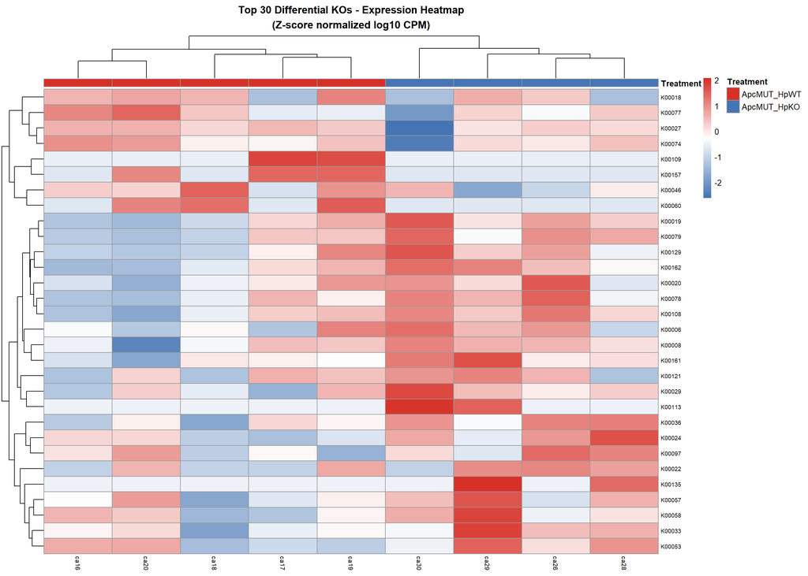

```r
# ------------------------------------------------------------------------------
# 热图：Top差异KO的丰度模式
# ------------------------------------------------------------------------------

# 获取Top 30差异KO
ko_top30 <- ko_maaslin2_results |>
  dplyr::arrange(qval) |>
  head(30) |>
  dplyr::pull(feature)

if (length(ko_top30) > 0) {
  # 提取CPM数据
  ko_heatmap_matrix <- assay(tse_ko_corepair, "cpm")[ko_top30, , drop = FALSE]

  # Log转换
  ko_heatmap_matrix <- log10(ko_heatmap_matrix + 1)

  # Z-score标准化（按行）
  ko_heatmap_scaled <- t(scale(t(ko_heatmap_matrix)))

  # 准备注释
  ko_sample_anno <- data.frame(
    Treatment = colData(tse_ko_corepair)$treatment_group,
    row.names = colnames(ko_heatmap_scaled)
  )

  # 注释颜色
  ko_anno_colors <- list(
    Treatment = c("ApcMUT_HpWT" = "#D73027", "ApcMUT_HpKO" = "#4575B4")
  )

  # 绘制热图
  p5_3_ko_heatmap <- pheatmap::pheatmap(
    ko_heatmap_scaled,
    annotation_col = ko_sample_anno,
    annotation_colors = ko_anno_colors,
    cluster_rows = TRUE,
    cluster_cols = TRUE,
    show_rownames = TRUE,
    show_colnames = TRUE,
    fontsize_row = 7,
    fontsize_col = 8,
    color = colorRampPalette(c("#4575B4", "white", "#D73027"))(100),
    main = "Top 30 Differential KOs - Expression Heatmap\n(Z-score normalized log10 CPM)",
    silent = TRUE
  )

  print(p5_3_ko_heatmap)

  png(path_target("18_ko_heatmap.png"), width = 14, height = 10, units = "in", res = 300)
  print(p5_3_ko_heatmap)
  dev.off()
} else {
  cat("没有足够的KO数据，跳过热图\n")
}
```

## 1.6 5.6 KO功能注释与富集

```r
# ------------------------------------------------------------------------------
# KO功能注释
# 将显著KO映射到KEGG通路和功能描述
# ------------------------------------------------------------------------------

# 获取显著KO列表
ko_sig_list <- ko_maaslin2_results |>
  dplyr::filter(qval < 0.25) |>
  dplyr::arrange(qval)

cat("=== 显著差异KO列表 (q < 0.25) ===\n")
```

```
=== 显著差异KO列表 (q < 0.25) ===
```

```r
cat("总数:", nrow(ko_sig_list), "\n\n")
```

```
总数: 0
```

```r
if (nrow(ko_sig_list) > 0) {
  # 显示详细信息
  ko_sig_display <- ko_sig_list |>
    dplyr::mutate(
      direction = ifelse(coef > 0, "↑ HpWT", "↑ HpKO"),
      effect = round(coef, 3),
      q_value = format(qval, digits = 3, scientific = TRUE)
    ) |>
    dplyr::select(feature, direction, effect, q_value)

  print(ko_sig_display)

  # 保存显著KO列表
  write.csv(
    ko_sig_list,
    file = path_target("19_significant_KOs.csv"),
    row.names = FALSE
  )

  cat("\n✓ 显著KO列表已保存\n")
} else {
  cat("未发现显著差异的KO (q < 0.25)\n")
}
```

```
未发现显著差异的KO (q < 0.25)
```

```r
# ------------------------------------------------------------------------------
# KO分析统计汇总
# ------------------------------------------------------------------------------

cat("========================================\n")
cat("   Part 5: KO基因家族分析结果汇总\n")
```

```
   Part 5: KO基因家族分析结果汇总
```

```r
cat("========================================\n\n")
cat("【数据概览】\n")
```

```
【数据概览】
```

```r
cat("- 输入KO总数:", nrow(ko_unstratified), "\n")
```

```
- 输入KO总数: 6107
```

```r
cat("- 过滤后KO数:", nrow(tse_ko_corepair), "\n")
```

```
- 过滤后KO数: 3947
```

```r
cat("- 分析样本数:", ncol(tse_ko_corepair), "\n\n")
```

```
- 分析样本数: 9
```

```r
cat("【差异分析结果】\n")
```

```
【差异分析结果】
```

```r
cat("- 显著KO (q < 0.05):", ko_sig_005, "\n")
```

```
- 显著KO (q < 0.05): 0
```

```r
cat("- 显著KO (q < 0.10):", ko_sig_010, "\n")
```

```
- 显著KO (q < 0.10): 0
```

```r
cat("- 显著KO (q < 0.25):", ko_sig_025, "\n\n")
```

```
- 显著KO (q < 0.25): 0
```

```r
if (ko_sig_025 > 0) {
  cat("【Top 5 差异KO】\n")
  top5_ko <- ko_maaslin2_results |>
    dplyr::arrange(qval) |>
    head(5)

  for (i in 1:nrow(top5_ko)) {
    direction <- ifelse(top5_ko$coef[i] > 0, "在HpWT中升高", "在HpWT中降低")
    cat(i, ". ", top5_ko$feature[i], "\n",
        "   ", direction, " (coef=", round(top5_ko$coef[i], 3),
        ", q=", format(top5_ko$qval[i], digits = 2), ")\n", sep = "")
  }
}

cat("\n【生物学意义】\n")
```

```
【生物学意义】
```

```r
cat("KO水平分析比通路分析更精细，能够发现：\n")
```

```
KO水平分析比通路分析更精细，能够发现：
```

```r
cat("1. 关键限速酶的差异表达\n")
```

```
1. 关键限速酶的差异表达
```

```r
cat("2. 毒力因子相关基因的变化\n")
```

```
2. 毒力因子相关基因的变化
```

```r
cat("3. 特定代谢功能的微生物差异\n")
```

```
3. 特定代谢功能的微生物差异
```

# 2 Part 6: 物种-功能整合分析 (Taxa-Function Integration)

虽然通路和KO水平的组间差异分析未发现显著结果，但我们可以通过**物种-功能关联分析**来探索： - 哪些物种与哪些功能（KO）强相关？ - 如果01分析发现的差异物种与特定功能相关，这仍然具有生物学意义

## 2.1 6.1 加载物种数据

> **注意**: 此部分分析需要 01qmd 生成的物种丰度数据。如果文件不存在，将自动跳过 Taxa-KO 关联分析。

```r
# ------------------------------------------------------------------------------
# 加载01分析的物种数据（可选，文件不存在则跳过）
# ------------------------------------------------------------------------------

species_rds_path <- here::here("data", "01_alpha_beta_diversity_analysis", "tse_standard_species_ca_cleaned.rds")
taxa_ko_analysis_available <- file.exists(species_rds_path)

if (taxa_ko_analysis_available) {
  tse_species_full <- readRDS(species_rds_path)

  cat("=== 物种数据概览 ===\n")
  cat("物种数:", nrow(tse_species_full), "\n")
  cat("样本数:", ncol(tse_species_full), "\n")

  # 筛选核心比较组样本
  tse_species_corepair <- tse_species_full[, tse_species_full$treatment_group %in% c("ApcMUT_HpWT", "ApcMUT_HpKO")]

  cat("\n筛选核心比较组后:\n")
  cat("样本数:", ncol(tse_species_corepair), "\n")
  print(table(colData(tse_species_corepair)$treatment_group))
} else {
  cat("=== 物种数据不可用 ===\n")
  cat("文件不存在:", species_rds_path, "\n")
  cat("Taxa-KO 关联分析将被跳过\n")
  cat("\n如需运行此分析，请先运行 01_alpha_beta_diversity_analysis.qmd\n")
}
```

```
=== 物种数据概览 ===
物种数: 11213
样本数: 28

筛选核心比较组后:
样本数: 9

ApcMUT_HpKO ApcMUT_HpWT
          4           5
```

```r
# ------------------------------------------------------------------------------
# 准备物种数据用于关联分析
# ------------------------------------------------------------------------------

# 计算相对丰度（如果还没有）
if (!"relabundance" %in% assayNames(tse_species_corepair)) {
  tse_species_corepair <- mia::transformAssay(
    tse_species_corepair,
    assay.type = "counts",
    method = "relabundance"
  )
}

cat("=== 物种筛选 ===\n")
```

```
=== 物种筛选 ===
```

```r
cat("原始物种数:", nrow(tse_species_corepair), "\n")
```

```
原始物种数: 11213
```

```r
# Step 1: Prevalence过滤（至少在10%样本中检测到）
species_prevalence <- rowSums(assay(tse_species_corepair, "counts") > 0) / ncol(tse_species_corepair)
species_pass_prev <- species_prevalence >= 0.1  # 10% prevalence

cat("通过prevalence过滤 (>=10%):", sum(species_pass_prev), "\n")
```

```
通过prevalence过滤 (>=10%): 10798
```

```r
# Step 2: 丰度过滤（平均相对丰度 > 0.1%）
species_mean_abund <- rowMeans(assay(tse_species_corepair, "relabundance"))
species_pass_abund <- species_mean_abund > 0.001  # 0.1%

cat("通过丰度过滤 (>0.1%):", sum(species_pass_abund), "\n")
```

```
通过丰度过滤 (>0.1%): 139
```

```r
# 同时满足两个条件
species_pass_both <- species_pass_prev & species_pass_abund

tse_species_filtered <- tse_species_corepair[species_pass_both, ]

cat("同时通过两个过滤:", nrow(tse_species_filtered), "\n")
```

```
同时通过两个过滤: 139
```

```r
# 显示保留的物种
cat("\n保留的物种:\n")
```

```
保留的物种:
```

```r
print(head(rownames(tse_species_filtered), 20))
```

```
 [1] "Microbacterium proteolyticum"
 [2] "Microbacterium testaceum"
 [3] "Mycobacterium canetti"
 [4] "Adlercreutzia equolifaciens"
 [5] "Blautia producta"
 [6] "Blautia pseudococcoides"
 [7] "Blautia massiliensis (ex Durand et al. 2017)"
 [8] "Blautia obeum"
 [9] "Blautia wexlerae"
[10] "Blautia parvula"
[11] "Blautia hydrogenotrophica"
[12] "Blautia argi"
[13] "Blautia hansenii"
[14] "Blautia luti"
[15] "Enterocloster bolteae"
[16] "Enterocloster clostridioformis"
[17] "Enterocloster lavalensis"
[18] "Enterocloster asparagiformis"
[19] "Roseburia sp. 499"
[20] "Roseburia sp. 831b"
```

## 2.2 6.2 准备KO数据

```r
# ------------------------------------------------------------------------------
# 准备KO数据用于关联分析
# ------------------------------------------------------------------------------

# 确保KO TSE存在
if (!exists("tse_ko_corepair")) {
  cat("错误: tse_ko_corepair不存在，请先运行Part 5\n")
} else {
  cat("=== KO数据筛选 ===\n")
  cat("原始KO数:", nrow(tse_ko_corepair), "\n")
  cat("样本数:", ncol(tse_ko_corepair), "\n")

  # Step 1: Prevalence过滤（至少在10%样本中检测到）
  ko_prevalence <- rowSums(assay(tse_ko_corepair, "counts") > 0) / ncol(tse_ko_corepair)
  ko_pass_prev <- ko_prevalence >= 0.1  # 10% prevalence

  cat("\n通过prevalence过滤 (>=10%):", sum(ko_pass_prev), "\n")

  # Step 2: 丰度过滤（平均CPM > 10）
  ko_mean_cpm <- rowMeans(assay(tse_ko_corepair, "cpm"))
  ko_pass_abund <- ko_mean_cpm > 10

  cat("通过丰度过滤 (CPM>10):", sum(ko_pass_abund), "\n")

  # 同时满足两个条件
  ko_pass_both <- ko_pass_prev & ko_pass_abund

  tse_ko_filtered <- tse_ko_corepair[ko_pass_both, ]

  cat("同时通过两个过滤:", nrow(tse_ko_filtered), "\n")
}
```

```
=== KO数据筛选 ===
原始KO数: 3947
样本数: 9

通过prevalence过滤 (>=10%): 3947
通过丰度过滤 (CPM>10): 3725
同时通过两个过滤: 3725
```

## 2.3 6.3 样本对齐

```r
# ------------------------------------------------------------------------------
# 确保物种和KO数据的样本一致
# ------------------------------------------------------------------------------

# 获取共同样本
taxa_samples <- colnames(tse_species_filtered)
ko_samples <- colnames(tse_ko_filtered)

common_samples <- base::intersect(taxa_samples, ko_samples)

cat("=== 样本对齐 ===\n")
```

```
=== 样本对齐 ===
```

```r
cat("物种数据样本数:", length(taxa_samples), "\n")
```

```
物种数据样本数: 9
```

```r
cat("KO数据样本数:", length(ko_samples), "\n")
```

```
KO数据样本数: 9
```

```r
cat("共同样本数:", length(common_samples), "\n")
```

```
共同样本数: 9
```

```r
# 子集化
tse_species_aligned <- tse_species_filtered[, common_samples]
tse_ko_aligned <- tse_ko_filtered[, common_samples]

cat("\n对齐后:\n")
```

```
对齐后:
```

```r
cat("物种TSE:", nrow(tse_species_aligned), "物种 x", ncol(tse_species_aligned), "样本\n")
```

```
物种TSE: 139 物种 x 9 样本
```

```r
cat("KO TSE:", nrow(tse_ko_aligned), "KO x", ncol(tse_ko_aligned), "样本\n")
```

```
KO TSE: 3725 KO x 9 样本
```

## 2.4 6.4 计算物种-KO关联

```r
# ------------------------------------------------------------------------------
# 使用getCrossAssociation计算物种-KO相关性
# 方法：Spearman相关（适合非正态分布的微生物数据）
# ------------------------------------------------------------------------------


# 进一步筛选以减少计算量（取Top物种和Top KO）
n_top_species <- min(30, nrow(tse_species_aligned))
n_top_ko <- min(50, nrow(tse_ko_aligned))

# 选择丰度最高的物种
species_abundance_order <- order(rowMeans(assay(tse_species_aligned, "relabundance")), decreasing = TRUE)
top_species_idx <- species_abundance_order[1:n_top_species]

# 选择丰度最高的KO
ko_abundance_order <- order(rowMeans(assay(tse_ko_aligned, "cpm")), decreasing = TRUE)
top_ko_idx <- ko_abundance_order[1:n_top_ko]

# 子集化
tse_species_top <- tse_species_aligned[top_species_idx, ]
tse_ko_top <- tse_ko_aligned[top_ko_idx, ]

cat("=== 关联分析输入 ===\n")
```

```
=== 关联分析输入 ===
```

```r
cat("Top物种数:", nrow(tse_species_top), "\n")
```

```
Top物种数: 30
```

```r
cat("Top KO数:", nrow(tse_ko_top), "\n")
```

```
Top KO数: 50
```

```r
# 准备矩阵用于相关性计算
species_matrix <- t(assay(tse_species_top, "relabundance"))
ko_matrix_for_cor <- t(assay(tse_ko_top, "cpm"))

# 对KO数据做log转换
ko_matrix_for_cor <- log10(ko_matrix_for_cor + 1)

cat("\n计算Spearman相关性...\n")
```

```
计算Spearman相关性...
```

```r
# 计算相关性矩阵
cor_matrix <- cor(species_matrix, ko_matrix_for_cor, method = "spearman")

cat("相关性矩阵维度:", dim(cor_matrix), "\n")
```

```
相关性矩阵维度: 30 50
```

```r
cat("相关性范围:", round(min(cor_matrix, na.rm = TRUE), 3), "to",
    round(max(cor_matrix, na.rm = TRUE), 3), "\n")
```

```
相关性范围: -0.967 to 0.983
```

```r
# ------------------------------------------------------------------------------
# 计算相关性的p值
# ------------------------------------------------------------------------------

# 初始化p值矩阵
pval_matrix <- matrix(NA, nrow = ncol(species_matrix), ncol = ncol(ko_matrix_for_cor))
rownames(pval_matrix) <- colnames(species_matrix)
colnames(pval_matrix) <- colnames(ko_matrix_for_cor)

# 计算每对的p值
for (i in 1:ncol(species_matrix)) {
  for (j in 1:ncol(ko_matrix_for_cor)) {
    test_result <- cor.test(species_matrix[, i], ko_matrix_for_cor[, j],
                           method = "spearman", exact = FALSE)
    pval_matrix[i, j] <- test_result$p.value
  }
}

# FDR校正
pval_adjusted <- matrix(p.adjust(as.vector(pval_matrix), method = "BH"),
                        nrow = nrow(pval_matrix), ncol = ncol(pval_matrix))
rownames(pval_adjusted) <- rownames(pval_matrix)
colnames(pval_adjusted) <- colnames(pval_matrix)

# 统计显著关联数
n_sig_005 <- sum(pval_adjusted < 0.05, na.rm = TRUE)
n_sig_010 <- sum(pval_adjusted < 0.10, na.rm = TRUE)
n_sig_025 <- sum(pval_adjusted < 0.25, na.rm = TRUE)

cat("=== 显著关联统计 ===\n")
```

```
=== 显著关联统计 ===
```

```r
cat("总测试数:", length(pval_adjusted), "\n")
```

```
总测试数: 1500
```

```r
cat("显著关联数 (FDR < 0.05):", n_sig_005, "\n")
```

```
显著关联数 (FDR < 0.05): 78
```

```r
cat("显著关联数 (FDR < 0.10):", n_sig_010, "\n")
```

```
显著关联数 (FDR < 0.10): 113
```

```r
cat("显著关联数 (FDR < 0.25):", n_sig_025, "\n")
```

```
显著关联数 (FDR < 0.25): 260
```

## 2.5 6.5 物种-功能关联热图

```r
# ------------------------------------------------------------------------------
# 热图：物种-KO相关性
# ------------------------------------------------------------------------------

# 筛选有显著关联的物种和KO
sig_threshold <- 0.25  # 使用宽松阈值确保有数据

# 找出至少有一个显著关联的物种和KO
species_with_sig <- rowSums(pval_adjusted < sig_threshold, na.rm = TRUE) > 0
ko_with_sig <- colSums(pval_adjusted < sig_threshold, na.rm = TRUE) > 0

cat("有显著关联的物种数:", sum(species_with_sig), "\n")
```

```
有显著关联的物种数: 29
```

```r
cat("有显著关联的KO数:", sum(ko_with_sig), "\n")
```

```
有显著关联的KO数: 45
```

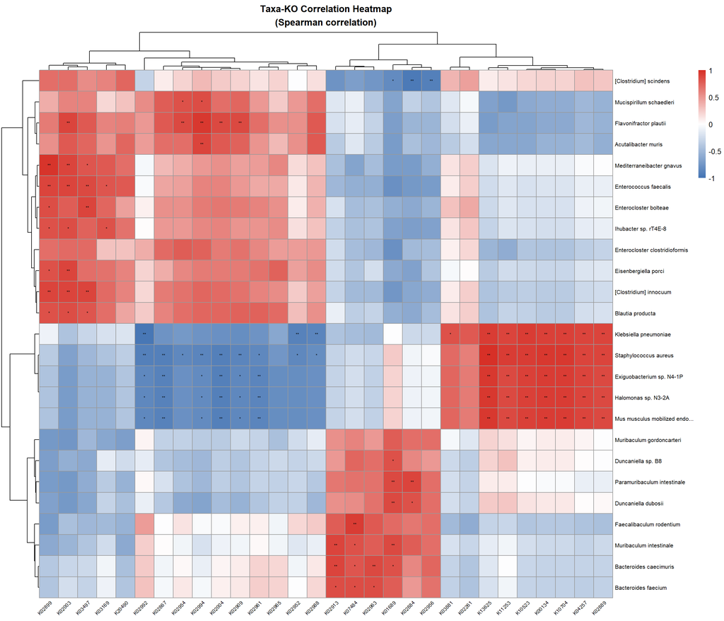

```
** = FDR < 0.05, * = FDR < 0.10
```

```r
if (sum(species_with_sig) > 0 && sum(ko_with_sig) > 0) {
  # 筛选相关性矩阵
  cor_matrix_sig <- cor_matrix[species_with_sig, ko_with_sig, drop = FALSE]
  pval_matrix_sig <- pval_adjusted[species_with_sig, ko_with_sig, drop = FALSE]

  # 限制显示数量
  if (nrow(cor_matrix_sig) > 25) {
    # 选择相关性绝对值最大的物种
    species_max_cor <- apply(abs(cor_matrix_sig), 1, max, na.rm = TRUE)
    top_species_idx <- order(species_max_cor, decreasing = TRUE)[1:25]
    cor_matrix_sig <- cor_matrix_sig[top_species_idx, , drop = FALSE]
    pval_matrix_sig <- pval_matrix_sig[top_species_idx, , drop = FALSE]
  }

  if (ncol(cor_matrix_sig) > 30) {
    # 选择相关性绝对值最大的KO
    ko_max_cor <- apply(abs(cor_matrix_sig), 2, max, na.rm = TRUE)
    top_ko_idx <- order(ko_max_cor, decreasing = TRUE)[1:30]
    cor_matrix_sig <- cor_matrix_sig[, top_ko_idx, drop = FALSE]
    pval_matrix_sig <- pval_matrix_sig[, top_ko_idx, drop = FALSE]
  }

  # 简化名称
  rownames(cor_matrix_sig) <- stringr::str_replace(rownames(cor_matrix_sig), ".*s__", "")
  rownames(cor_matrix_sig) <- stringr::str_trunc(rownames(cor_matrix_sig), 30)
  colnames(cor_matrix_sig) <- stringr::str_trunc(colnames(cor_matrix_sig), 20)

  # 创建显著性标记矩阵
  sig_marks <- ifelse(pval_matrix_sig < 0.05, "**",
                      ifelse(pval_matrix_sig < 0.10, "*", ""))

  # 绘制热图
  p6_1_taxa_ko_heatmap <- pheatmap::pheatmap(
    cor_matrix_sig,
    color = colorRampPalette(c("#4575B4", "white", "#D73027"))(100),
    breaks = seq(-1, 1, length.out = 101),
    cluster_rows = TRUE,
    cluster_cols = TRUE,
    show_rownames = TRUE,
    show_colnames = TRUE,
    fontsize_row = 8,
    fontsize_col = 7,
    angle_col = 45,
    main = "Taxa-KO Correlation Heatmap\n(Spearman correlation)",
    display_numbers = sig_marks,
    number_color = "black",
    fontsize_number = 6,
    silent = TRUE
  )

  print(p6_1_taxa_ko_heatmap)

  png(path_target("20_taxa_ko_correlation_heatmap.png"),
      width = 14, height = 12, units = "in", res = 300)
  print(p6_1_taxa_ko_heatmap)
  dev.off()

  cat("\n** = FDR < 0.05, * = FDR < 0.10\n")
} else {
  cat("没有足够的显著关联用于绑图\n")

  # 即使没有显著关联，也显示相关性最强的组合
  cat("\n显示相关性最强的组合（不考虑显著性）:\n")
  cor_matrix_display <- cor_matrix[1:min(20, nrow(cor_matrix)),
                                    1:min(25, ncol(cor_matrix)), drop = FALSE]

  rownames(cor_matrix_display) <- stringr::str_replace(rownames(cor_matrix_display), ".*s__", "")
  rownames(cor_matrix_display) <- stringr::str_trunc(rownames(cor_matrix_display), 30)
  colnames(cor_matrix_display) <- stringr::str_trunc(colnames(cor_matrix_display), 20)

  p6_1_taxa_ko_heatmap <- pheatmap::pheatmap(
    cor_matrix_display,
    color = colorRampPalette(c("#4575B4", "white", "#D73027"))(100),
    breaks = seq(-1, 1, length.out = 101),
    cluster_rows = TRUE,
    cluster_cols = TRUE,
    show_rownames = TRUE,
    show_colnames = TRUE,
    fontsize_row = 8,
    fontsize_col = 7,
    angle_col = 45,
    main = "Taxa-KO Correlation Heatmap (Top associations)\n(Spearman correlation, for exploratory purpose)",
    silent = TRUE
  )

  print(p6_1_taxa_ko_heatmap)

  png(path_target("20_taxa_ko_correlation_heatmap.png"),
      width = 14, height = 12, units = "in", res = 300)
  print(p6_1_taxa_ko_heatmap)
  dev.off()
}
```

## 2.6 6.6 Top关联物种-KO对

```r
# ------------------------------------------------------------------------------
# 提取并展示Top关联的物种-KO对
# ------------------------------------------------------------------------------

# 将相关性矩阵转换为长格式
cor_long <- reshape2::melt(cor_matrix)
colnames(cor_long) <- c("Species", "KO", "Correlation")

pval_long <- reshape2::melt(pval_adjusted)
colnames(pval_long) <- c("Species", "KO", "FDR")

# 合并
associations <- dplyr::left_join(cor_long, pval_long, by = c("Species", "KO"))

# 添加绝对相关性
associations$Abs_Correlation <- abs(associations$Correlation)

# 简化物种名
associations$Species_short <- stringr::str_replace(as.character(associations$Species), ".*s__", "")

# 按绝对相关性排序
top_associations <- associations |>
  dplyr::arrange(desc(Abs_Correlation)) |>
  head(30)

cat("=== Top 30 物种-KO关联 ===\n")
```

```
=== Top 30 物种-KO关联 ===
```

```r
cat("(按相关性绝对值排序)\n\n")
```

```
(按相关性绝对值排序)
```

```r
top_display <- top_associations |>
  dplyr::mutate(
    Direction = ifelse(Correlation > 0, "+", "-"),
    Cor = round(Correlation, 3),
    FDR_display = format(FDR, digits = 2, scientific = TRUE)
  ) |>
  dplyr::select(Species_short, KO, Direction, Cor, FDR_display)

print(as.data.frame(top_display))
```

```
                                           Species_short     KO Direction
1                                  Staphylococcus aureus K13625         +
2                              Mediterraneibacter gnavus K02899         +
3                                  Klebsiella pneumoniae K02992         -
4                                  Staphylococcus aureus K00134         +
5                                 [Clostridium] scindens K02884         -
6                                 Flavonifractor plautii K02994         +
7                                    Halomonas sp. N3-2A K13625         +
8  Mus musculus mobilized endogenous polytropic provirus K13625         +
9                              Exiguobacterium sp. N4-1P K13625         +
10                                 Staphylococcus aureus K10704         +
11                                   Halomonas sp. N3-2A K00134         +
12 Mus musculus mobilized endogenous polytropic provirus K00134         +
13                             Exiguobacterium sp. N4-1P K00134         +
14                                 Klebsiella pneumoniae K10523         +
```

[output cut: 47 more lines]

```r
# 保存完整关联表
write.csv(
  associations |> dplyr::arrange(FDR),
  file = path_target("21_taxa_ko_associations.csv"),
  row.names = FALSE
)

cat("\n✓ 物种-KO关联表已保存\n")
```

```
✓ 物种-KO关联表已保存
```

## 2.7 6.7 关联网络可视化

```r
# ------------------------------------------------------------------------------
# 网络图：物种-KO关联
# 只显示较强的关联 (|r| > 0.5)
# ------------------------------------------------------------------------------

# 筛选强关联
strong_associations <- associations |>
  dplyr::filter(Abs_Correlation > 0.5)

cat("强关联数 (|r| > 0.5):", nrow(strong_associations), "\n")
```

```
强关联数 (|r| > 0.5): 496
```

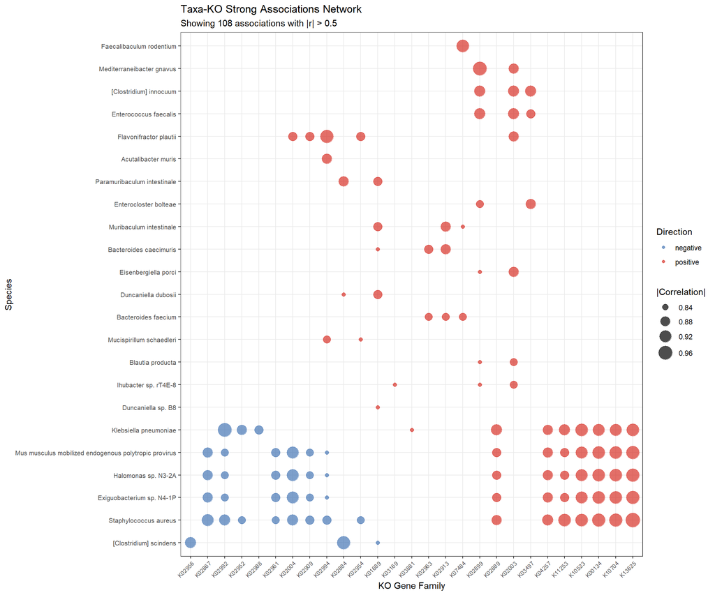

```r
if (nrow(strong_associations) >= 5) {
  # 限制数量
  if (nrow(strong_associations) > 100) {
    strong_associations <- strong_associations |>
      dplyr::slice_max(order_by = Abs_Correlation, n = 100)
  }

  # 准备网络数据
  network_data <- strong_associations |>
    dplyr::mutate(
      from = Species_short,
      to = as.character(KO),
      weight = Abs_Correlation,
      color = ifelse(Correlation > 0, "positive", "negative")
    ) |>
    dplyr::select(from, to, weight, color, Correlation, FDR)

  # 创建节点数据
  species_nodes <- data.frame(
    name = unique(network_data$from),
    type = "Species",
    stringsAsFactors = FALSE
  )

  ko_nodes <- data.frame(
    name = unique(network_data$to),
    type = "KO",
    stringsAsFactors = FALSE
  )

  nodes <- rbind(species_nodes, ko_nodes)

  # 使用ggplot2创建网络可视化（简化版）
  # 将网络数据转换为适合ggplot的格式

  # 创建点图展示强关联
  p6_2_network <- ggplot(
    network_data,
    aes(x = reorder(to, Correlation), y = reorder(from, Correlation))
  ) +
    geom_point(aes(size = weight, color = color), alpha = 0.7) +
    scale_color_manual(
      values = c("positive" = "#D73027", "negative" = "#4575B4"),
      name = "Direction"
    ) +
    scale_size_continuous(name = "|Correlation|", range = c(2, 8)) +
    labs(
      title = "Taxa-KO Strong Associations Network",
      subtitle = paste0("Showing ", nrow(network_data), " associations with |r| > 0.5"),
      x = "KO Gene Family",
      y = "Species"
    ) +
    theme_bw() +
    theme(
      axis.text.x = element_text(angle = 45, hjust = 1, size = 7),
      axis.text.y = element_text(size = 8),
      legend.position = "right"
    )

  print(p6_2_network)

  ggsave(
    path_target("22_taxa_ko_network.png"),
    p6_2_network,
    width = 12, height = 10, dpi = 300
  )
} else {
  cat("强关联数不足，使用更宽松的阈值展示...\n")

  # 使用更宽松的阈值
  moderate_associations <- associations |>
    dplyr::filter(Abs_Correlation > 0.3) |>
    dplyr::slice_max(order_by = Abs_Correlation, n = 50)

  if (nrow(moderate_associations) > 0) {
    p6_2_network <- ggplot(
      moderate_associations,
      aes(x = reorder(as.character(KO), Correlation),
          y = reorder(Species_short, Correlation))
    ) +
      geom_point(aes(size = Abs_Correlation,
                     color = ifelse(Correlation > 0, "positive", "negative")),
                 alpha = 0.7) +
      scale_color_manual(
        values = c("positive" = "#D73027", "negative" = "#4575B4"),
        name = "Direction"
      ) +
      scale_size_continuous(name = "|Correlation|", range = c(2, 8)) +
      labs(
        title = "Taxa-KO Associations (|r| > 0.3)",
        subtitle = "Top 50 associations shown",
        x = "KO Gene Family",
        y = "Species"
      ) +
      theme_bw() +
      theme(
        axis.text.x = element_text(angle = 45, hjust = 1, size = 7),
        axis.text.y = element_text(size = 8),
        legend.position = "right"
      )

    print(p6_2_network)

    ggsave(
      path_target("22_taxa_ko_network.png"),
      p6_2_network,
      width = 12, height = 10, dpi = 300
    )
  }
}
```

## 2.8 6.8 整合01分析的差异物种

```r
# ------------------------------------------------------------------------------
# 查看01分析中的差异物种与功能的关联
# ------------------------------------------------------------------------------

# 尝试加载01分析的差异分析结果
# 使用ANCOM-BC或ALDEx2的物种差异结果
dir_01 <- here::here("data", "01_alpha_beta_diversity_analysis")

ancombc_file <- file.path(dir_01, "18_daa_ancombc_top10_species.csv")
aldex2_file <- file.path(dir_01, "20_daa_aldex2_significant_species.csv")

diff_taxa <- NULL
diff_source <- ""

if (file.exists(ancombc_file)) {
  diff_taxa <- read.csv(ancombc_file)
  diff_source <- "ANCOM-BC"
  cat("=== 加载ANCOM-BC差异物种结果 ===\n")
} else if (file.exists(aldex2_file)) {
  diff_taxa <- read.csv(aldex2_file)
  diff_source <- "ALDEx2"
  cat("=== 加载ALDEx2差异物种结果 ===\n")
}
```

```
=== 加载ANCOM-BC差异物种结果 ===
```

```r
if (!is.null(diff_taxa) && nrow(diff_taxa) > 0) {
  cat("来源:", diff_source, "\n")
  cat("差异物种数:", nrow(diff_taxa), "\n\n")

  # 显示列名
  cat("列名:", paste(colnames(diff_taxa), collapse = ", "), "\n\n")
  print(head(diff_taxa, 10))

  # 查找taxon列
  taxon_col <- NULL
  for (col in c("taxon", "Species", "species", "feature", "X")) {
    if (col %in% colnames(diff_taxa)) {
      taxon_col <- col
      break
    }
  }

  if (!is.null(taxon_col)) {
    diff_species_names <- diff_taxa[[taxon_col]]
    diff_species_short <- stringr::str_replace(diff_species_names, ".*s__", "")

    cat("\n差异物种 (简化名):\n")
    print(diff_species_short)

    # 在关联表中查找
    diff_species_associations <- associations |>
      dplyr::filter(Species %in% diff_species_names |
                    Species_short %in% diff_species_short) |>
      dplyr::arrange(desc(Abs_Correlation))

    if (nrow(diff_species_associations) > 0) {
      cat("\n=== 差异物种的功能关联 (Top 20) ===\n")
      print(head(diff_species_associations |>
        dplyr::select(Species_short, KO, Correlation, FDR), 20))

      # 保存
      write.csv(diff_species_associations,
        file = path_target("23_differential_taxa_ko_associations.csv"),
        row.names = FALSE)
      cat("\n✓ 差异物种-KO关联已保存\n")
    } else {
      cat("\n差异物种未在Top关联分析中找到\n")
    }
  }
} else {
  cat("未找到01分析的差异物种文件\n")
}
```

```
来源: ANCOM-BC
差异物种数: 10

列名: taxon, p_treatment_groupApcMUT_HpWT, q_treatment_groupApcMUT_HpWT, lfc_treatment_groupApcMUT_HpWT

                                 taxon p_treatment_groupApcMUT_HpWT
1        Microbacterium sp. nov. GSS16                  0.009393182
2             Microbacterium sp. LKL04                  0.009980731
3  Microbacterium trichothecenolyticum                  0.006692324
4             Microbacterium terricola                  0.006308883
5             Microbacterium lushaniae                  0.006590145
6           Microbacterium caowuchunii                  0.004509353
7    Microbacterium hydrocarbonoxydans                  0.009543073
8             Microbacterium sediminis                  0.001383167
9             Pseudarthrobacter sp. H2                  0.008932442
10                 Kocuria turfanensis                  0.009926458
   q_treatment_groupApcMUT_HpWT lfc_treatment_groupApcMUT_HpWT
1                     0.1942202                     -1.2183692
2                     0.1942202                     -1.4737772
3                     0.1942202                     -1.2684134
4                     0.1942202                     -1.6019392
5                     0.1942202                     -1.3826046
6                     0.1942202                     -1.4505803
7                     0.1942202                     -1.1074346
8                     0.1942202                     -1.4249033
9                     0.1942202                      0.4777780
10                    0.1942202                      0.6983797

差异物种 (简化名):
 [1] "Microbacterium sp. nov. GSS16"       "Microbacterium sp. LKL04"
 [3] "Microbacterium trichothecenolyticum" "Microbacterium terricola"
 [5] "Microbacterium lushaniae"            "Microbacterium caowuchunii"
 [7] "Microbacterium hydrocarbonoxydans"   "Microbacterium sediminis"
 [9] "Pseudarthrobacter sp. H2"            "Kocuria turfanensis"

差异物种未在Top关联分析中找到
```

## 2.9 6.9 Part 6 小结

```r
cat("========================================\n")
cat("   Part 6: 物种-功能整合分析小结\n")
```

```
   Part 6: 物种-功能整合分析小结
```

```r
cat("========================================\n\n")
cat("【分析概览】\n")
```

```
【分析概览】
```

```r
cat("- 分析物种数:", nrow(tse_species_top), "\n")
```

```
- 分析物种数: 30
```

```r
cat("- 分析KO数:", nrow(tse_ko_top), "\n")
```

```
- 分析KO数: 50
```

```r
cat("- 总测试关联数:", length(pval_adjusted), "\n\n")
```

```
- 总测试关联数: 1500
```

```r
cat("【关联发现】\n")
```

```
【关联发现】
```

```r
cat("- 显著关联 (FDR < 0.05):", n_sig_005, "\n")
```

```
- 显著关联 (FDR < 0.05): 78
```

```r
cat("- 显著关联 (FDR < 0.10):", n_sig_010, "\n")
```

```
- 显著关联 (FDR < 0.10): 113
```

```r
cat("- 显著关联 (FDR < 0.25):", n_sig_025, "\n")
```

```
- 显著关联 (FDR < 0.25): 260
```

```r
cat("- 强关联 (|r| > 0.5):", sum(associations$Abs_Correlation > 0.5, na.rm = TRUE), "\n\n")
```

```
- 强关联 (|r| > 0.5): 496
```

```r
# 显示最强关联
cat("【Top 5 最强关联】\n")
```

```
【Top 5 最强关联】
```

```r
top5_assoc <- associations |>
  dplyr::arrange(desc(Abs_Correlation)) |>
  head(5)

for (i in 1:nrow(top5_assoc)) {
  direction <- ifelse(top5_assoc$Correlation[i] > 0, "正相关", "负相关")
  cat(i, ". ", top5_assoc$Species_short[i], " ↔ ", as.character(top5_assoc$KO[i]), "\n",
      "   r = ", round(top5_assoc$Correlation[i], 3), " (", direction, ")\n", sep = "")
}
```

```
1. Staphylococcus aureus ↔ K13625
   r = 0.983 (正相关)
2. Mediterraneibacter gnavus ↔ K02899
   r = 0.967 (正相关)
3. Klebsiella pneumoniae ↔ K02992
   r = -0.967 (负相关)
4. Staphylococcus aureus ↔ K00134
   r = 0.95 (正相关)
5. [Clostridium] scindens ↔ K02884
   r = -0.95 (负相关)
```

```r
cat("\n【生物学意义】\n")
```

```
【生物学意义】
```

```r
cat("物种-功能关联分析揭示了微生物组的功能结构：\n")
```

```
物种-功能关联分析揭示了微生物组的功能结构：
```

```r
cat("1. 正相关：物种丰度↑ → 功能丰度↑（该物种贡献该功能）\n")
```

```
1. 正相关：物种丰度↑ → 功能丰度↑（该物种贡献该功能）
```

```r
cat("2. 负相关：物种丰度↑ → 功能丰度↓（竞争或抑制关系）\n")
```

```
2. 负相关：物种丰度↑ → 功能丰度↓（竞争或抑制关系）
```

```r
cat("3. 即使组间差异不显著，强关联仍有生物学价值\n")
```

```
3. 即使组间差异不显著，强关联仍有生物学价值
```

```r
cat("\n【输出文件】\n")
```

```
【输出文件】
```

```r
cat("- 20_taxa_ko_correlation_heatmap.png: 物种-KO相关性热图\n")
```

```
- 20_taxa_ko_correlation_heatmap.png: 物种-KO相关性热图
```

```r
cat("- 21_taxa_ko_associations.csv: 完整关联表\n")
```

```
- 21_taxa_ko_associations.csv: 完整关联表
```

```r
cat("- 22_taxa_ko_network.png: 关联网络图\n")
```

```
- 22_taxa_ko_network.png: 关联网络图
```

# 3 Part 7: KO驱动物种分析 (KO Driver Species Analysis)

Part 6发现了强物种-KO关联，现在我们需要用**stratified数据**来验证： - 这些强相关的KO在两组间是由哪些物种贡献的？ - 是所有物种同步变化，还是特定”驱动物种”主导？

## 3.1 7.1 加载KO Stratified数据

```r
# ------------------------------------------------------------------------------
# 加载KO stratified数据
# 格式：KO_ID|species → abundance
# ------------------------------------------------------------------------------

ko_stratified_file <- here::here(
  "data/00-raw/d02_functional_profiling/humann4",
  "humann4_genefamilies-step3-KO_stratified.tsv"
)

ko_stratified <- read.delim(ko_stratified_file, header = TRUE, sep = "\t")

cat("=== KO Stratified数据 ===\n")
```

```
=== KO Stratified数据 ===
```

```r
cat("总行数:", nrow(ko_stratified), "\n")
```

```
总行数: 21394
```

```r
cat("列数:", ncol(ko_stratified), "\n")
```

```
列数: 34
```

```r
# 查看数据结构
cat("\n前几行示例:\n")
```

```
前几行示例:
```

```r
print(head(ko_stratified[, 1:4], 5))
```

```
  X..Gene.Family.HUMAnN.v4.0.0.alpha.1.Adjusted.CPMs      ca01     ca02
1    UNGROUPED|s__Acutalibacter_SGB43256.t__SGB43256 17.364144 9.976283
2       UNGROUPED|s__Acutalibacter_muris.t__SGB43254  9.164464 7.140867
3  UNGROUPED|s__Acutalibacter_sp_1XD8_33.t__SGB29419  8.980404 6.697984
4  UNGROUPED|s__Adlercreutzia_mucosicola.t__SGB33554  0.000000 0.000000
5       UNGROUPED|s__Adlercreutzia_muris.t__SGB33553  0.000000 0.000000
      ca03
1 31.33794
2 33.31291
3 12.30627
4  0.00000
5  0.00000
```

```r
# ------------------------------------------------------------------------------
# 解析KO|species格式
# ------------------------------------------------------------------------------

# 获取第一列名称
ko_first_col <- colnames(ko_stratified)[1]

# 解析KO和物种
ko_stratified_parsed <- ko_stratified |>
  dplyr::mutate(
    original_id = .data[[ko_first_col]],
    ko_id = stringr::str_extract(original_id, "^[^|]+"),
    species = stringr::str_extract(original_id, "\\|(.+)$") |>
      stringr::str_remove("^\\|")
  ) |>
  # 只保留有物种注释的行
  dplyr::filter(!is.na(species) & species != "")

# 清理样本列名
sample_cols <- base::setdiff(colnames(ko_stratified_parsed),
                             c(ko_first_col, "original_id", "ko_id", "species"))
colnames(ko_stratified_parsed) <- gsub("_Abundance$", "", colnames(ko_stratified_parsed))

cat("=== 解析后数据 ===\n")
```

```
=== 解析后数据 ===
```

```r
cat("KO-物种组合数:", nrow(ko_stratified_parsed), "\n")
```

```
KO-物种组合数: 21394
```

```r
cat("唯一KO数:", length(unique(ko_stratified_parsed$ko_id)), "\n")
```

```
唯一KO数: 6107
```

```r
cat("唯一物种数:", length(unique(ko_stratified_parsed$species)), "\n")
```

```
唯一物种数: 326
```

## 3.2 7.2 提取强相关KO的驱动物种

```r
# ------------------------------------------------------------------------------
# 提取Part 6中发现的强相关KO
# ------------------------------------------------------------------------------

# 获取Top 20强相关的KO（按相关性绝对值）
top_correlated_kos <- associations |>
  dplyr::arrange(desc(Abs_Correlation)) |>
  dplyr::distinct(KO, .keep_all = TRUE) |>  # 每个KO只取最强关联
  head(20) |>
  dplyr::pull(KO) |>
  as.character()

cat("=== Top 20 强相关KO ===\n")
```

```
=== Top 20 强相关KO ===
```

```r
print(top_correlated_kos)
```

```
 [1] "K13625" "K02899" "K02992" "K00134" "K02884" "K02994" "K10704" "K10523"
 [9] "K07484" "K11253" "K02004" "K02867" "K04257" "K02003" "K02889" "K02956"
[17] "K03497" "K02913" "K02952" "K02961"
```

```r
# 从stratified数据中筛选这些KO
ko_driver_data <- ko_stratified_parsed |>
  dplyr::filter(ko_id %in% top_correlated_kos)

cat("\n筛选到的KO-物种组合数:", nrow(ko_driver_data), "\n")
```

```
筛选到的KO-物种组合数: 1015
```

```r
# ------------------------------------------------------------------------------
# 计算每个物种对各KO的贡献
# ------------------------------------------------------------------------------

# 获取核心比较组样本
corepair_sample_ids <- colnames(tse_ko_corepair)

# 更新样本列名
sample_cols_updated <- gsub("_Abundance$", "", sample_cols)
available_samples <- base::intersect(corepair_sample_ids, colnames(ko_driver_data))

cat("可用样本数:", length(available_samples), "\n")
```

```
可用样本数: 9
```

```r
if (length(available_samples) > 0) {
  # 计算每个KO-物种组合在各组的平均丰度
  ko_driver_summary <- ko_driver_data |>
    dplyr::select(ko_id, species, dplyr::all_of(available_samples)) |>
    tidyr::pivot_longer(
      cols = dplyr::all_of(available_samples),
      names_to = "sample_id",
      values_to = "abundance"
    ) |>
    # 添加分组信息
    dplyr::left_join(
      sample_metadata_ko |> dplyr::select(sample_id, treatment_group),
      by = "sample_id"
    ) |>
    dplyr::filter(!is.na(treatment_group)) |>
    # 计算每组平均值
    dplyr::group_by(ko_id, species, treatment_group) |>
    dplyr::summarise(
      mean_abundance = mean(abundance, na.rm = TRUE),
      .groups = "drop"
    )

  cat("\n=== KO驱动物种汇总 ===\n")
  cat("汇总行数:", nrow(ko_driver_summary), "\n")
  cat("涉及KO数:", length(unique(ko_driver_summary$ko_id)), "\n")
  cat("涉及物种数:", length(unique(ko_driver_summary$species)), "\n")
}
```

```
=== KO驱动物种汇总 ===
汇总行数: 2030
涉及KO数: 20
涉及物种数: 264
```

## 3.3 7.3 KO驱动物种堆叠柱状图

```
堆叠柱状图数据行数: 78
```

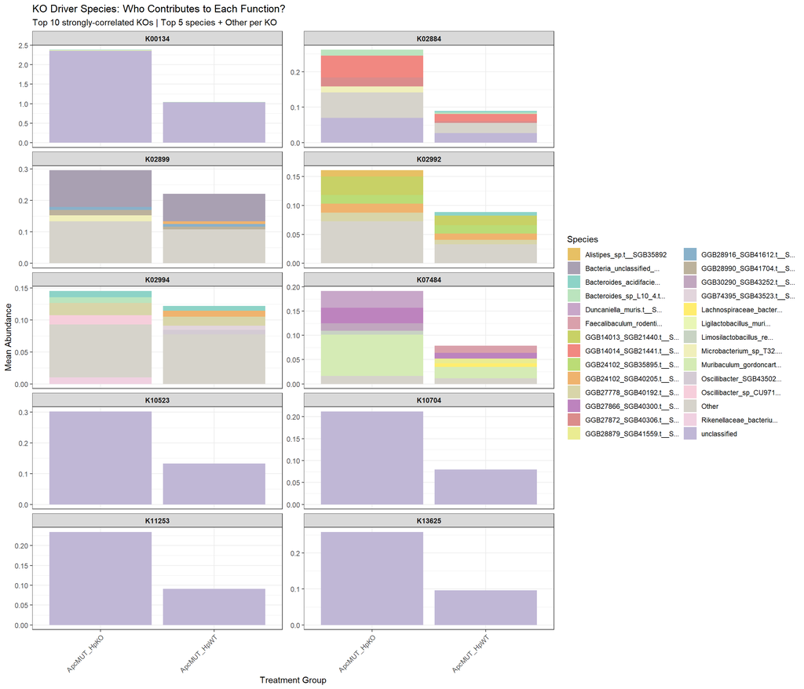

```r
# ------------------------------------------------------------------------------
# 堆叠柱状图：展示各KO在两组中的物种贡献
# ------------------------------------------------------------------------------

if (exists("ko_driver_summary") && nrow(ko_driver_summary) > 0) {
  # 选择Top 10 KO
  top10_kos <- associations |>
    dplyr::arrange(desc(Abs_Correlation)) |>
    dplyr::distinct(KO, .keep_all = TRUE) |>
    head(10) |>
    dplyr::pull(KO) |>
    as.character()

  # 筛选数据并处理物种名称
  ko_bar_data <- ko_driver_summary |>
    dplyr::filter(ko_id %in% top10_kos) |>
    dplyr::mutate(
      species_short = stringr::str_replace(species, ".*s__", ""),
      species_short = stringr::str_trunc(species_short, 25),
      ko_short = stringr::str_trunc(ko_id, 15)
    ) |>
    # 每个KO只保留Top 5贡献物种
    dplyr::group_by(ko_id, treatment_group) |>
    dplyr::mutate(
      rank = rank(-mean_abundance, ties.method = "first"),
      species_grouped = ifelse(rank <= 5, species_short, "Other")
    ) |>
    dplyr::group_by(ko_id, ko_short, treatment_group, species_grouped) |>
    dplyr::summarise(
      mean_abundance = sum(mean_abundance),
      .groups = "drop"
    )

  cat("堆叠柱状图数据行数:", nrow(ko_bar_data), "\n")

  if (nrow(ko_bar_data) > 0 && length(unique(ko_bar_data$ko_short)) > 0) {
    # 创建颜色
    n_species <- length(unique(ko_bar_data$species_grouped))
    if (n_species <= 12) {
      species_colors <- RColorBrewer::brewer.pal(max(3, n_species), "Set3")
    } else {
      species_colors <- colorRampPalette(RColorBrewer::brewer.pal(12, "Set3"))(n_species)
    }
    names(species_colors) <- unique(ko_bar_data$species_grouped)

    # 堆叠柱状图
    p7_1_ko_driver_bar <- ggplot(
      ko_bar_data,
      aes(x = treatment_group, y = mean_abundance, fill = species_grouped)
    ) +
      geom_bar(stat = "identity", position = "stack") +
      facet_wrap(~ ko_short, scales = "free_y", ncol = 2) +
      scale_fill_manual(values = species_colors, name = "Species") +
      labs(
        title = "KO Driver Species: Who Contributes to Each Function?",
        subtitle = "Top 10 strongly-correlated KOs | Top 5 species + Other per KO",
        x = "Treatment Group",
        y = "Mean Abundance"
      ) +
      theme_bw() +
      theme(
        axis.text.x = element_text(angle = 45, hjust = 1),
        strip.text = element_text(size = 9, face = "bold"),
        legend.position = "right"
      )

    print(p7_1_ko_driver_bar)

    ggsave(
      path_target("24_ko_driver_species_stacked_bar.png"),
      p7_1_ko_driver_bar,
      width = 14, height = 12, dpi = 300
    )
  }
} else {
  cat("KO驱动物种数据不可用\n")
}
```

## 3.4 7.4 KO贡献变化热图

```
聚合后数据行数: 99
热图矩阵维度: 48 x 20
筛选后矩阵维度: 30 x 15
差异值范围: -1.32 到 0.024
95%百分位数: 0.021
颜色轴范围: -0.1 到 0.1
```

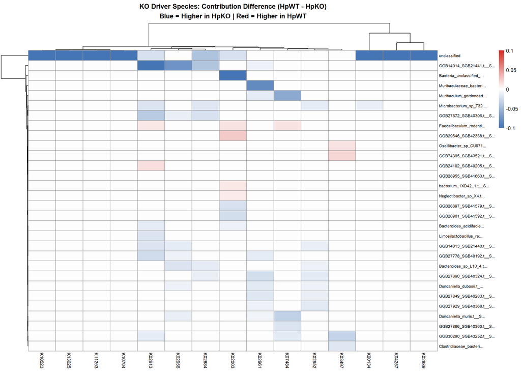

```
✓ 热图已保存
```

```r
# ------------------------------------------------------------------------------
# 热图：物种对各KO的贡献变化
# ------------------------------------------------------------------------------

if (exists("ko_driver_summary") && nrow(ko_driver_summary) > 0) {
  # 计算组间差异
  ko_driver_diff <- ko_driver_summary |>
    tidyr::pivot_wider(
      names_from = treatment_group,
      values_from = mean_abundance,
      values_fill = 0
    )

  # 检查两组列是否存在
  if ("ApcMUT_HpWT" %in% colnames(ko_driver_diff) &&
      "ApcMUT_HpKO" %in% colnames(ko_driver_diff)) {

    ko_driver_diff <- ko_driver_diff |>
      dplyr::mutate(
        diff_abundance = ApcMUT_HpWT - ApcMUT_HpKO,
        species_short = stringr::str_replace(species, ".*s__", ""),
        species_short = stringr::str_trunc(species_short, 25),
        ko_short = stringr::str_trunc(ko_id, 12)
      ) |>
      dplyr::filter(abs(diff_abundance) > 0)  # 只保留有差异的

    # 筛选差异最大的组合
    top_diff <- ko_driver_diff |>
      dplyr::slice_max(order_by = abs(diff_abundance), n = 100)

    if (nrow(top_diff) > 0) {
      # 先聚合确保每个species-KO组合唯一（防止pivot_wider报错）
      top_diff_aggregated <- top_diff |>
        dplyr::group_by(species_short, ko_short) |>
        dplyr::summarise(
          diff_abundance = sum(diff_abundance, na.rm = TRUE),
          .groups = "drop"
        )

      cat("聚合后数据行数:", nrow(top_diff_aggregated), "\n")

      # 创建热图矩阵
      heatmap_matrix <- top_diff_aggregated |>
        tidyr::pivot_wider(
          names_from = ko_short,
          values_from = diff_abundance,
          values_fill = 0
        ) |>
        tibble::column_to_rownames("species_short") |>
        as.matrix()

      cat("热图矩阵维度:", nrow(heatmap_matrix), "x", ncol(heatmap_matrix), "\n")

      # 限制维度
      if (nrow(heatmap_matrix) > 30) {
        row_order <- order(rowSums(abs(heatmap_matrix)), decreasing = TRUE)[1:30]
        heatmap_matrix <- heatmap_matrix[row_order, , drop = FALSE]
      }
      if (ncol(heatmap_matrix) > 15) {
        col_order <- order(colSums(abs(heatmap_matrix)), decreasing = TRUE)[1:15]
        heatmap_matrix <- heatmap_matrix[, col_order, drop = FALSE]
      }

      cat("筛选后矩阵维度:", nrow(heatmap_matrix), "x", ncol(heatmap_matrix), "\n")

      # 确保矩阵有足够的行列
      if (nrow(heatmap_matrix) >= 2 && ncol(heatmap_matrix) >= 2) {
        # 使用95%百分位数设置颜色范围（避免极端值拉宽范围）
        all_values <- as.vector(heatmap_matrix)
        q95 <- quantile(abs(all_values), 0.95, na.rm = TRUE)
        color_limit <- max(q95, 0.1)  # 至少0.1，避免太小

        cat("差异值范围:", round(min(heatmap_matrix), 3), "到",
            round(max(heatmap_matrix), 3), "\n")
        cat("95%百分位数:", round(q95, 3), "\n")
        cat("颜色轴范围:", round(-color_limit, 3), "到", round(color_limit, 3), "\n")

        # 对称颜色范围
        color_breaks <- seq(-color_limit, color_limit, length.out = 101)

        # 绘制热图（对称颜色轴）
        p7_2_ko_driver_heatmap <- pheatmap::pheatmap(
          heatmap_matrix,
          color = colorRampPalette(c("#4575B4", "white", "#D73027"))(100),
          breaks = color_breaks,  # 使用对称的breaks
          cluster_rows = TRUE,
          cluster_cols = TRUE,
          show_rownames = TRUE,
          show_colnames = TRUE,
          fontsize_row = 8,
          fontsize_col = 9,
          main = "KO Driver Species: Contribution Difference (HpWT - HpKO)\nBlue = Higher in HpKO | Red = Higher in HpWT"
        )

        # 保存到文件
        png(path_target("25_ko_driver_contribution_heatmap.png"),
            width = 14, height = 10, units = "in", res = 300)
        grid::grid.newpage()
        grid::grid.draw(p7_2_ko_driver_heatmap$gtable)
        dev.off()

        cat("✓ 热图已保存\n")
      } else {
        cat("矩阵维度不足，无法绑制热图\n")
      }
    }
  }
} else {
  cat("ko_driver_summary不存在或为空\n")
}
```

## 3.5 7.5 关键驱动物种识别

```r
# ------------------------------------------------------------------------------
# 识别关键驱动物种：在多个KO中贡献变化大的物种
# ------------------------------------------------------------------------------

if (exists("ko_driver_diff") && nrow(ko_driver_diff) > 0 &&
    "diff_abundance" %in% colnames(ko_driver_diff)) {

  key_ko_drivers <- ko_driver_diff |>
    dplyr::group_by(species_short) |>
    dplyr::summarise(
      n_kos = n(),
      total_diff = sum(abs(diff_abundance)),
      mean_diff = mean(diff_abundance),
      direction = ifelse(mean_diff > 0, "Higher in HpWT", "Higher in HpKO"),
      .groups = "drop"
    ) |>
    dplyr::arrange(desc(total_diff))

  cat("=== 关键KO驱动物种 (Top 15) ===\n")
  cat("这些物种在多个强相关KO中贡献变化最大\n\n")

  print(head(key_ko_drivers, 15))

  # 保存结果
  write.csv(
    key_ko_drivers,
    file = path_target("26_key_ko_driver_species.csv"),
    row.names = FALSE
  )

  cat("\n✓ 关键驱动物种列表已保存\n")
}
```

```
=== 关键KO驱动物种 (Top 15) ===
这些物种在多个强相关KO中贡献变化最大

# A tibble: 15 × 5
   species_short             n_kos total_diff mean_diff direction
   <chr>                     <int>      <dbl>     <dbl> <chr>
 1 unclassified                 12     3.35    -0.279   Higher in HpKO
 2 GGB14014_SGB21441.t__S...     4     0.251   -0.0627  Higher in HpKO
 3 Bacteria_unclassified_...    35     0.179   -0.00370 Higher in HpKO
 4 Muribaculaceae_bacteri...    20     0.155   -0.00754 Higher in HpKO
 5 Muribaculum_gordoncart...    10     0.101   -0.00979 Higher in HpKO
 6 Bacteroides_sp_L10_4.t...    13     0.0820  -0.00628 Higher in HpKO
 7 Microbacterium_sp_T32....     5     0.0783  -0.0157  Higher in HpKO
 8 GGB30290_SGB43252.t__S...     7     0.0758  -0.0108  Higher in HpKO
 9 GGB27872_SGB40306.t__S...     4     0.0698  -0.0174  Higher in HpKO
10 GGB27778_SGB40192.t__S...     7     0.0651  -0.00865 Higher in HpKO
11 Bacteroides_acidifacie...    12     0.0637  -0.00527 Higher in HpKO
12 Faecalibaculum_rodenti...    13     0.0633   0.00487 Higher in HpWT
13 Duncaniella_dubosii.t_...     6     0.0624  -0.0104  Higher in HpKO
14 GGB14013_SGB21440.t__S...     5     0.0616  -0.0123  Higher in HpKO
15 Duncaniella_muris.t__S...     5     0.0569  -0.0114  Higher in HpKO

✓ 关键驱动物种列表已保存
```

## 3.6 7.6 Part 7 小结

```r
cat("========================================\n")
cat("   Part 7: KO驱动物种分析小结\n")
```

```
   Part 7: KO驱动物种分析小结
```

```r
cat("========================================\n\n")
if (exists("key_ko_drivers") && nrow(key_ko_drivers) > 0) {
  cat("【分析概览】\n")
  cat("- 分析的强相关KO数: 20\n")
  cat("- 涉及的驱动物种数:", nrow(key_ko_drivers), "\n\n")

  cat("【关键发现】\n")
  cat("Top 5 驱动物种（影响最多KO的物种）:\n\n")

  for (i in 1:min(5, nrow(key_ko_drivers))) {
    cat(i, ". ", key_ko_drivers$species_short[i], "\n",
        "   影响KO数: ", key_ko_drivers$n_kos[i], "\n",
        "   方向: ", key_ko_drivers$direction[i], "\n",
        "   总贡献差异: ", round(key_ko_drivers$total_diff[i], 2), "\n\n", sep = "")
  }

  cat("【生物学意义】\n")
  cat("驱动物种分析揭示了功能变化的微生物学基础：\n")
  cat("1. 如果同一KO由不同物种主导 → 功能替代/补偿\n")
  cat("2. 如果特定物种驱动多个KO变化 → 该物种是'功能枢纽'\n")
  cat("3. 结合01分析的物种差异结果 → 验证因果关系\n")
} else {
  cat("驱动物种数据不可用\n")
}
```

[output not shown]

```r
cat("\n【输出文件】\n")
```

```
【输出文件】
```

```r
cat("- 24_ko_driver_species_stacked_bar.png: KO驱动物种堆叠柱状图\n")
```

```
- 24_ko_driver_species_stacked_bar.png: KO驱动物种堆叠柱状图
```

```r
cat("- 25_ko_driver_contribution_heatmap.png: KO贡献变化热图\n")
```

```
- 25_ko_driver_contribution_heatmap.png: KO贡献变化热图
```

```r
cat("- 26_key_ko_driver_species.csv: 关键驱动物种列表\n")
```

```
- 26_key_ko_driver_species.csv: 关键驱动物种列表
```